# TEAM-C

Reenu, Tom, Lee, Erik,

7 April 2019

# Advanced Analytics - Assignment 2

# analyses

# Decision tree

# ———————————————————–

# description

This data set includes descriptions of hypothetical samples corresponding to 23 species of gilled mushrooms in the Agaricus and Lepiota Family (pp. 500-525). Each species is identified as definitely edible, definitely poisonous, or of unknown edibility and not recommended. This latter class was combined with the poisonous one. The Guide clearly states that there is no simple rule for determining the edibility of a mushroom; no rule like ``leaflets three, let it be’’ for Poisonous Oak and Ivy. Number of Instances: 8124 Number of Attributes: 22 (all nominally valued) Attribute Information: (classes: edible=e, poisonous=p) 1. cap-shape: bell=b,conical=c,convex=x,flat=f, knobbed=k,sunken=s 2. cap-surface: fibrous=f,grooves=g,scaly=y,smooth=s 3. cap-color: brown=n,buff=b,cinnamon=c,gray=g,green=r, pink=p,purple=u,red=e,white=w,yellow=y 4. bruises?: bruises=t,no=f 5. odor: almond=a,anise=l,creosote=c,fishy=y,foul=f, musty=m,none=n,pungent=p,spicy=s 6. gill-attachment: attached=a,descending=d,free=f,notched=n 7. gill-spacing: close=c,crowded=w,distant=d 8. gill-size: broad=b,narrow=n 9. gill-color: black=k,brown=n,buff=b,chocolate=h,gray=g, green=r,orange=o,pink=p,purple=u,red=e,white=w,yellow=y 10. stalk-shape: enlarging=e,tapering=t 11. stalk-root: bulbous=b,club=c,cup=u,equal=e,rhizomorphs=z,rooted=r,missing=? 12. stalk-surface-above-ring: fibrous=f,scaly=y,silky=k,smooth=s 13. stalk-surface-below-ring: fibrous=f,scaly=y,silky=k,smooth=s 14. stalk-color-above-ring: brown=n,buff=b,cinnamon=c,gray=g,orange=o,pink=p,red=e,white=w,yellow=y 15. stalk-color-below-ring: brown=n,buff=b,cinnamon=c,gray=g,orange=o, pink=p,red=e,white=w,yellow=y 16. veil-type: partial=p,universal=u 17. veil-color: brown=n,orange=o,white=w,yellow=y 18. ring-number: none=n,one=o,two=t 19. ring-type: cobwebby=c,evanescent=e,flaring=f,large=l, one=n,pendant=p,sheathing=s,zone=z 20. spore-print-color: black=k,brown=n,buff=b,chocolate=h,green=r,orange=o,purple=u,white=w,yellow=y 21. population: abundant=a,clustered=c,numerous=n, scattered=s,several=v,solitary=y 22. habitat: grasses=g,leaves=l,meadows=m,paths=p, urban=u,waste=w,woods=d

from the data set we am going to try predict the edibility of a mushroom fist we must look and investigate the dataset to try identify what may need to be changed

```r
#inspect the data
str(mushrooms)
```

```
## 'data.frame':    8124 obs. of  23 variables:
##  $ class                   : Factor w/ 2 levels "e","p": 2 1 1 2 1 1 1 1 2 1 ...
##  $ cap.shape               : Factor w/ 6 levels "b","c","f","k",..: 6 6 1 6 6 6 1 1 6 1 ...
##  $ cap.surface             : Factor w/ 4 levels "f","g","s","y": 3 3 3 4 3 4 3 4 4 3 ...
##  $ cap.color               : Factor w/ 10 levels "b","c","e","g",..: 5 10 9 9 4 10 9 9 9 10 ...
##  $ bruises                 : Factor w/ 2 levels "f","t": 2 2 2 2 1 2 2 2 2 2 ...
##  $ odor                    : Factor w/ 9 levels "a","c","f","l",..: 7 1 4 7 6 1 1 4 7 1 ...
##  $ gill.attachment         : Factor w/ 2 levels "a","f": 2 2 2 2 2 2 2 2 2 2 ...
##  $ gill.spacing            : Factor w/ 2 levels "c","w": 1 1 1 1 2 1 1 1 1 1 ...
##  $ gill.size               : Factor w/ 2 levels "b","n": 2 1 1 2 1 1 1 1 2 1 ...
##  $ gill.color              : Factor w/ 12 levels "b","e","g","h",..: 5 5 6 6 5 6 3 6 8 3 ...
##  $ stalk.shape             : Factor w/ 2 levels "e","t": 1 1 1 1 2 1 1 1 1 1 ...
##  $ stalk.root              : Factor w/ 5 levels "?","b","c","e",..: 4 3 3 4 4 3 3 3 4 3 ...
##  $ stalk.surface.above.ring: Factor w/ 4 levels "f","k","s","y": 3 3 3 3 3 3 3 3 3 3 ...
##  $ stalk.surface.below.ring: Factor w/ 4 levels "f","k","s","y": 3 3 3 3 3 3 3 3 3 3 ...
##  $ stalk.color.above.ring  : Factor w/ 9 levels "b","c","e","g",..: 8 8 8 8 8 8 8 8 8 8 ...
##  $ stalk.color.below.ring  : Factor w/ 9 levels "b","c","e","g",..: 8 8 8 8 8 8 8 8 8 8 ...
##  $ veil.type               : Factor w/ 1 level "p": 1 1 1 1 1 1 1 1 1 1 ...
##  $ veil.color              : Factor w/ 4 levels "n","o","w","y": 3 3 3 3 3 3 3 3 3 3 ...
##  $ ring.number             : Factor w/ 3 levels "n","o","t": 2 2 2 2 2 2 2 2 2 2 ...
##  $ ring.type               : Factor w/ 5 levels "e","f","l","n",..: 5 5 5 5 1 5 5 5 5 5 ...
##  $ spore.print.color       : Factor w/ 9 levels "b","h","k","n",..: 3 4 4 3 4 3 3 4 3 3 ...
##  $ population              : Factor w/ 6 levels "a","c","n","s",..: 4 3 3 4 1 3 3 4 5 4 ...
##  $ habitat                 : Factor w/ 7 levels "d","g","l","m",..: 6 2 4 6 2 2 4 4 2 4 ...
```

```r
summary(mushrooms)
```

```
##  class    cap.shape cap.surface   cap.color    bruises       odor
##  e:4208   b: 452    f:2320      n      :2284   f:4748   n      :3528
##  p:3916   c:   4    g:   4      g      :1840   t:3376   f      :2160
##           f:3152    s:2556      e      :1500            s      : 576
##           k: 828    y:3244      y      :1072            y      : 576
##           s:  32                w      :1040            a      : 400
##           x:3656                b      : 168            l      : 400
##                                 (Other): 220            (Other): 484
##  gill.attachment gill.spacing gill.size   gill.color   stalk.shape
##  a: 210          c:6812       b:5612    b      :1728   e:3516
##  f:7914          w:1312       n:2512    p      :1492   t:4608
##                                         w      :1202
##                                         n      :1048
##                                         g      : 752
##                                         h      : 732
##                                         (Other):1170
##  stalk.root stalk.surface.above.ring stalk.surface.below.ring
##  ?:2480     f: 552                   f: 600
##  b:3776     k:2372                   k:2304
##  c: 556     s:5176                   s:4936
##  e:1120     y:  24                   y: 284
##  r: 192
##
##
##  stalk.color.above.ring stalk.color.below.ring veil.type veil.color
##  w      :4464           w      :4384           p:8124    n:  96
##  p      :1872           p      :1872                     o:  96
##  g      : 576           g      : 576                     w:7924
##  n      : 448           n      : 512                     y:   8
##  b      : 432           b      : 432
##  o      : 192           o      : 192
##  (Other): 140           (Other): 156
##  ring.number ring.type spore.print.color population habitat
##  n:  36      e:2776    w      :2388      a: 384     d:3148
##  o:7488      f:  48    n      :1968      c: 340     g:2148
##  t: 600      l:1296    k      :1872      n: 400     l: 832
##              n:  36    h      :1632      s:1248     m: 292
##              p:3968    r      :  72      v:4040     p:1144
##                        b      :  48      y:1712     u: 368
##                        (Other): 144                 w: 192
```

```r
#Count NAs
sapply(mushrooms, function(x){sum(is.na(x))})
```

```
##                    class                cap.shape              cap.surface
##                        0                        0                        0
##                cap.color                  bruises                     odor
##                        0                        0                        0
##          gill.attachment             gill.spacing                gill.size
##                        0                        0                        0
##               gill.color              stalk.shape               stalk.root
##                        0                        0                        0
## stalk.surface.above.ring stalk.surface.below.ring   stalk.color.above.ring
##                        0                        0                        0
##   stalk.color.below.ring                veil.type               veil.color
##                        0                        0                        0
##              ring.number                ring.type        spore.print.color
##                        0                        0                        0
##               population                  habitat
##                        0                        0
```

```r
#count blank entries
sapply(mushrooms, function(x){sum(x=='', na.rm=T)})
```

```
##                    class                cap.shape              cap.surface
##                        0                        0                        0
##                cap.color                  bruises                     odor
##                        0                        0                        0
##          gill.attachment             gill.spacing                gill.size
##                        0                        0                        0
##               gill.color              stalk.shape               stalk.root
##                        0                        0                        0
## stalk.surface.above.ring stalk.surface.below.ring   stalk.color.above.ring
##                        0                        0                        0
##   stalk.color.below.ring                veil.type               veil.color
##                        0                        0                        0
##              ring.number                ring.type        spore.print.color
##                        0                        0                        0
##               population                  habitat
##                        0                        0
```

Rename the variables. We have to give names to each variable and then specify the category for each variable.This adds meaning tho what we are doing but it is not neccessary for what we need to do

check to make sure that all the variables are indeed changed to factors

```r
#check to make sure that all the variables are indeed changed to factors
glimpse(mushrooms)
```

```
## Observations: 8,124
## Variables: 23
## $ edibility                <fct> poisonous, edible, edible, poisonous,...
## $ cap_shape                <fct> convex, convex, bell, convex, convex,...
## $ cap_surface              <fct> scaly, scaly, scaly, smooth, scaly, s...
## $ cap_color                <fct> brown, yellow, white, white, gray, ye...
## $ bruises                  <fct> yes, yes, yes, yes, no, yes, yes, yes...
## $ odor                     <fct> pungent, almond, anise, pungent, none...
## $ gill_attachement         <fct> free, free, free, free, free, free, f...
## $ gill_spacing             <fct> close, close, close, close, crowded, ...
## $ gill_size                <fct> narrow, broad, broad, narrow, broad, ...
## $ gill_color               <fct> black, black, brown, brown, black, br...
## $ stalk_shape              <fct> enlarging, enlarging, enlarging, enla...
## $ stalk_root               <fct> equal, club, club, equal, equal, club...
## $ stalk_surface_above_ring <fct> smooth, smooth, smooth, smooth, smoot...
## $ stalk_surface_below_ring <fct> smooth, smooth, smooth, smooth, smoot...
## $ stalk_color_above_ring   <fct> purple, purple, purple, purple, purpl...
## $ stalk_color_below_ring   <fct> purple, purple, purple, purple, purpl...
## $ veil_type                <fct> partial, partial, partial, partial, p...
## $ veil_color               <fct> white, white, white, white, white, wh...
## $ ring_number              <fct> one, one, one, one, one, one, one, on...
## $ ring_type                <fct> pendant, pendant, pendant, pendant, e...
## $ spore_print_color        <fct> black, brown, brown, black, brown, bl...
## $ population               <fct> scattered, numerous, numerous, scatte...
## $ habitat                  <fct> urban, grasses, meadows, urban, grass...
```

```r
#From the the results we can see that every variable is marke dwith a <fct> which states they are all indeed changed to factors

#every variable we have is categorical, so we need to see the number of categories we are talking about
numClass <- function(x){
  x <- length(levels(x))
}
x <- mushrooms %>% map_dbl(function(.x) numClass(.x)) %>% as_tibble() %>%
  rownames_to_column() %>% arrange(desc(value))
colnames(x) <- c("Variable name", "Number of levels")
print(x)
```

```
## # A tibble: 23 x 2
##    `Variable name`        `Number of levels`
##    <chr>                               <dbl>
##  1 gill_color                             12
##  2 cap_color                              10
##  3 stalk_color_above_ring                 10
##  4 stalk_color_below_ring                 10
##  5 odor                                    9
##  6 spore_print_color                       9
##  7 habitat                                 7
##  8 cap_shape                               6
##  9 population                              6
## 10 stalk_root                              5
## # ... with 13 more rows
```

From the results we can see that gill_color has the most levels with 12 followed by cap_color and both stalk_colors

the veil type only has one categorical factor therefore its completely useless to us and may even negatively effect the outcome of the modelling stage.So i had to take away the column

```r
mushrooms <- mushrooms %>% select(- veil_type)
#i then have to see if there is any missing data as algorithm will not work otherwise
map_dbl(mushrooms, function(.x) {sum(is.na(.x))})
```

```
##                edibility                cap_shape              cap_surface
##                        0                        0                        0
##                cap_color                  bruises                     odor
##                        0                        0                        0
##         gill_attachement             gill_spacing                gill_size
##                        0                        0                        0
##               gill_color              stalk_shape               stalk_root
##                        0                        0                        0
## stalk_surface_above_ring stalk_surface_below_ring   stalk_color_above_ring
##                        0                        0                        0
##   stalk_color_below_ring               veil_color              ring_number
##                        0                        0                        0
##                ring_type        spore_print_color               population
##                        0                        0                        0
##                  habitat
##                        0
```

```r
#from the results we can see that there is luckily no data missing
```

for us to continue with the model i have to split the data into test and train sets

```r
set.seed(1810)
mushsample <- caret::createDataPartition(y = mushrooms$edibility, times = 1, p = 0.8, list = FALSE)
trainMush <- mushrooms[mushsample, ]
testMush <- mushrooms[-mushsample, ]
# now i can check the splits in regards to the predicted variable
#original
round(prop.table(table(mushrooms$edibility)), 2)
```

```
##
##    edible poisonous
##      0.52      0.48
```

```r
#train
round(prop.table(table(trainMush$edibility)), 2)
```

```
##
##    edible poisonous
##      0.52      0.48
```

```r
#test
round(prop.table(table(testMush$edibility)), 2)
```

```
##
##    edible poisonous
##      0.52      0.48
```

Start Regression Tree

```r
#because of the amount of categorical variables regression trees are the ideal amount
set.seed(1810)
regTree <- rpart(edibility ~ ., data = trainMush, method = "class")
regTree
```

```
## n= 6500
##
## node), split, n, loss, yval, (yprob)
##       * denotes terminal node
##
## 1) root 6500 3133 edible (0.51800000 0.48200000)
##   2) odor=almond,anise,none 3468  101 edible (0.97087659 0.02912341)
##     4) spore_print_color=buff,chocolate,black,brown,orange,purple,white,yellow 3408   41 edible (0.98796948 0.01203052) *
##     5) spore_print_color=green 60    0 poisonous (0.00000000 1.00000000) *
##   3) odor=creosote,foul,musty,pungent,spicy,fishy 3032    0 poisonous (0.00000000 1.00000000) *
```

```r
#
caret::confusionMatrix(data=predict(regTree, type = "class"),
                       reference = trainMush$edibility,
                       positive="edible")
```

```
## Confusion Matrix and Statistics
##
##            Reference
## Prediction  edible poisonous
##   edible      3367        41
##   poisonous      0      3092
##
##                Accuracy : 0.9937
##                  95% CI : (0.9915, 0.9955)
##     No Information Rate : 0.518
##     P-Value [Acc > NIR] : < 2.2e-16
##
##                   Kappa : 0.9874
##
##  Mcnemar's Test P-Value : 4.185e-10
##
##             Sensitivity : 1.0000
##             Specificity : 0.9869
##          Pos Pred Value : 0.9880
##          Neg Pred Value : 1.0000
##              Prevalence : 0.5180
##          Detection Rate : 0.5180
##    Detection Prevalence : 0.5243
##       Balanced Accuracy : 0.9935
##
##        'Positive' Class : edible
##
```

A confusion/error matrix that lets us know what the model is getting right and what it is getting wrong / errors its making. it also states how accurate the algorithm is so you can see whether the the algorithm is worthwhile and results are trustworthy

from the results it shows us that 41 mushrooms were put as edible but they were actually poisonous i will us cp and penalty matrix parameters in order to give out predictions. the best way to change this is to set up a penalty matrix in the rpart of the function the penalty matrix penalizes the higher order differences to allow for a more accurate result

```r
penalty_matrix <- matrix(c(0, 1, 10, 0), byrow = TRUE, nrow = 2)
penalty_mod_tree <- rpart(edibility ~ ., data = trainMush, method = "class",
                            parms = list(loss = penalty_matrix))

caret::confusionMatrix(data=predict(penalty_mod_tree, type = "class"),
                       reference = trainMush$edibility,
                       positive="edible")
```

```
## Confusion Matrix and Statistics
##
##            Reference
## Prediction  edible poisonous
##   edible      3367         0
##   poisonous      0      3133
##
##                Accuracy : 1
##                  95% CI : (0.9994, 1)
##     No Information Rate : 0.518
##     P-Value [Acc > NIR] : < 2.2e-16
##
##                   Kappa : 1
##
##  Mcnemar's Test P-Value : NA
##
##             Sensitivity : 1.000
##             Specificity : 1.000
##          Pos Pred Value : 1.000
##          Neg Pred Value : 1.000
##              Prevalence : 0.518
##          Detection Rate : 0.518
##    Detection Prevalence : 0.518
##       Balanced Accuracy : 1.000
##
##        'Positive' Class : edible
##
```

introducing the penalty matrix gives out a perfect prediction 100% accuracy with 3367 edible and 3133 poisonous

using a cp parameter also increases the accuracy of the model the cp model basically controls and measures the complexity of the tree based off how large the user may want it, in order to get the cp we need to idenify the cross validation errors, which is basically a technique used to help estimate the test error of a predictive model such as the one we are implimenting we start off with a very deep tree that can be pruned later

```r
regTree <- rpart(edibility ~ ., data = trainMush,
                    method = "class", cp = 0.00001)
```

to use cp we have to to identify the cp with the smallest cross validation error which can be doen using printcp and plotcp

```r
#printcp
printcp(regTree)
```

```
##
## Classification tree:
## rpart(formula = edibility ~ ., data = trainMush, method = "class",
##     cp = 1e-05)
##
## Variables actually used in tree construction:
## [1] cap_surface            habitat                odor
## [4] spore_print_color      stalk_color_below_ring stalk_root
##
## Root node error: 3133/6500 = 0.482
##
## n= 6500
##
##          CP nsplit rel error    xerror       xstd
## 1 0.9677625      0 1.0000000 1.0000000 0.01285833
## 2 0.0191510      1 0.0322375 0.0322375 0.00318273
## 3 0.0063837      2 0.0130865 0.0130865 0.00203731
## 4 0.0022343      3 0.0067028 0.0067028 0.00146032
## 5 0.0011171      5 0.0022343 0.0022343 0.00084402
## 6 0.0000100      7 0.0000000 0.0022343 0.00084402
```

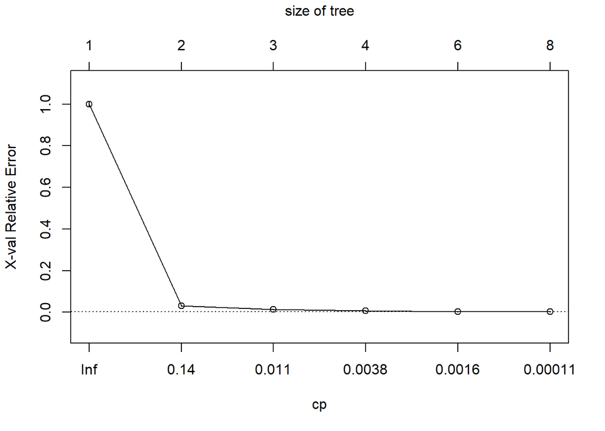

```r
#the results show that the smallest cp happened after the 5th split
plotcp(regTree)
```

```r
regTree$cptable[which.min(regTree$cptable[, "xerror"]), "CP"]
```

```
## [1] 0.00111714
```

pruning is done to trim down the tree to try make is as simple as possible in order to reduce the overallcomplexity of the tree its mostly done in order to limit the chances of overfitting a tree and making it useless to user now we can start pruning the tree with the cp that gives lowest cross validation error

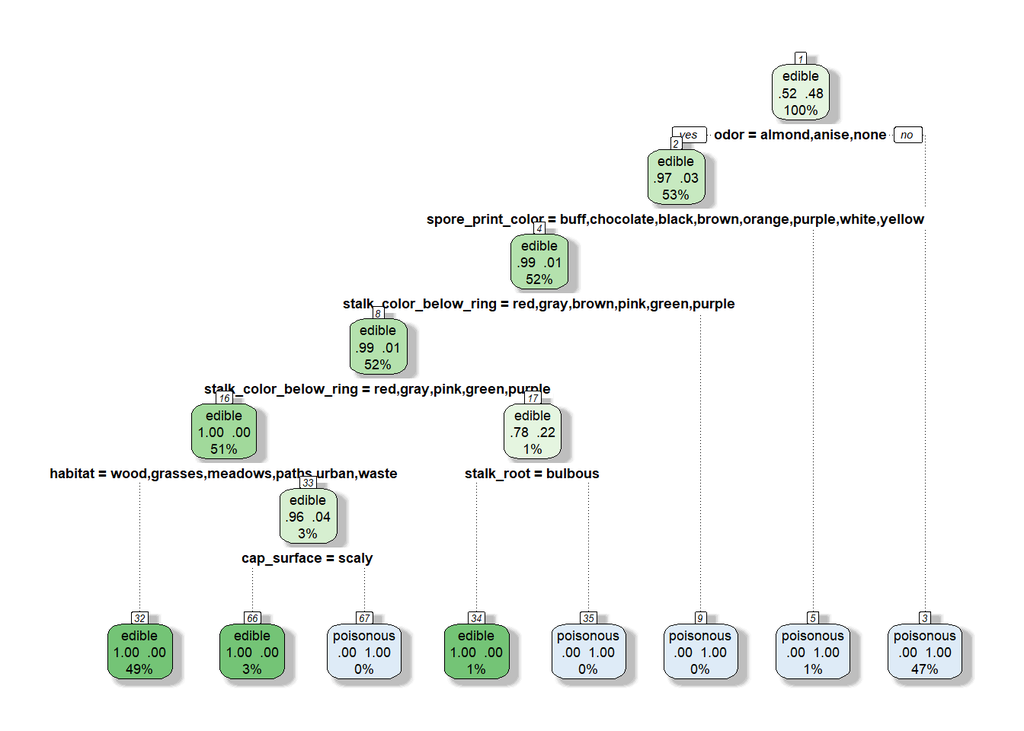

```r
bestcp <- round(regTree$cptable[which.min(regTree$cptable[, "xerror"]), "CP"], 4)
regTree_pruned <- prune(regTree, cp = bestcp)

#now we can have a look at the tree as it stands now
rpart.plot(regTree_pruned, extra = 104, box.palette = "GnBu",
           branch.lty = 3, shadow.col = "gray", nn = TRUE)
```

```r
#now we have to see how the model performs on the train data
#table(trainMush$edibility, predict(regTree, type="class"))

caret::confusionMatrix(data=predict(regTree_pruned, type = "class"),
                       reference = trainMush$edibility,
                       positive="edible")
```

```
## Confusion Matrix and Statistics
##
##            Reference
## Prediction  edible poisonous
##   edible      3367         0
##   poisonous      0      3133
##
##                Accuracy : 1
##                  95% CI : (0.9994, 1)
##     No Information Rate : 0.518
##     P-Value [Acc > NIR] : < 2.2e-16
##
##                   Kappa : 1
##
##  Mcnemar's Test P-Value : NA
##
##             Sensitivity : 1.000
##             Specificity : 1.000
##          Pos Pred Value : 1.000
##          Neg Pred Value : 1.000
##              Prevalence : 0.518
##          Detection Rate : 0.518
##    Detection Prevalence : 0.518
##       Balanced Accuracy : 1.000
##
##        'Positive' Class : edible
##
```

we can see that there are no poisonous values that should have been edible and visa versa. 3367 edible 3133 poisonous

```r
testTree <- predict(regTree, newdata = testMush)
caret::confusionMatrix(data = predict(regTree, newdata = testMush, type = "class"),
                       reference = testMush$edibility,
                       positive = "edible")
```

```
## Confusion Matrix and Statistics
##
##            Reference
## Prediction  edible poisonous
##   edible       841         0
##   poisonous      0       783
##
##                Accuracy : 1
##                  95% CI : (0.9977, 1)
##     No Information Rate : 0.5179
##     P-Value [Acc > NIR] : < 2.2e-16
##
##                   Kappa : 1
##
##  Mcnemar's Test P-Value : NA
##
##             Sensitivity : 1.0000
##             Specificity : 1.0000
##          Pos Pred Value : 1.0000
##          Neg Pred Value : 1.0000
##              Prevalence : 0.5179
##          Detection Rate : 0.5179
##    Detection Prevalence : 0.5179
##       Balanced Accuracy : 1.0000
##
##        'Positive' Class : edible
##
```

# Knn

# ———————————————————–

data source: https://archive.ics.uci.edu/ml/datasets/Wine 178 rows, 14 columns on chemical analysis of wines grown in the same region in Italy but derived from three different cultivars

```r
#exploring the data
str(wine)
```

```
## 'data.frame':    178 obs. of  14 variables:
##  $ V1 : int  1 1 1 1 1 1 1 1 1 1 ...
##  $ V2 : num  14.2 13.2 13.2 14.4 13.2 ...
##  $ V3 : num  1.71 1.78 2.36 1.95 2.59 1.76 1.87 2.15 1.64 1.35 ...
##  $ V4 : num  2.43 2.14 2.67 2.5 2.87 2.45 2.45 2.61 2.17 2.27 ...
##  $ V5 : num  15.6 11.2 18.6 16.8 21 15.2 14.6 17.6 14 16 ...
##  $ V6 : int  127 100 101 113 118 112 96 121 97 98 ...
##  $ V7 : num  2.8 2.65 2.8 3.85 2.8 3.27 2.5 2.6 2.8 2.98 ...
##  $ V8 : num  3.06 2.76 3.24 3.49 2.69 3.39 2.52 2.51 2.98 3.15 ...
##  $ V9 : num  0.28 0.26 0.3 0.24 0.39 0.34 0.3 0.31 0.29 0.22 ...
##  $ V10: num  2.29 1.28 2.81 2.18 1.82 1.97 1.98 1.25 1.98 1.85 ...
##  $ V11: num  5.64 4.38 5.68 7.8 4.32 6.75 5.25 5.05 5.2 7.22 ...
##  $ V12: num  1.04 1.05 1.03 0.86 1.04 1.05 1.02 1.06 1.08 1.01 ...
##  $ V13: num  3.92 3.4 3.17 3.45 2.93 2.85 3.58 3.58 2.85 3.55 ...
##  $ V14: int  1065 1050 1185 1480 735 1450 1290 1295 1045 1045 ...
```

```r
names(wine) <- c("Class","Alcohol","Malic_acid","Ash","Alcalinity_of_ash","Magnesium",
                 "Total_phenols","Flavanoids","Nonflavanoid_phenols",
                 "Proanthocyanins","Colour_intensity","Hue","OD280/OD315","Proline")

#table of wine class
table(wine$Class)
```

```
##
##  1  2  3
## 59 71 48
```

```r
# Show classes as percent of total
round(prop.table(table(wine$Class)) * 100, digits = 1)
```

```
##
##    1    2    3
## 33.1 39.9 27.0
```

create normalization function

```r
normalize <- function(x) {
  return ((x - min(x)) / (max(x) - min(x)))
}

# normalize the data so all numeric values are between 0 and 1
wine_norm <- as.data.frame(lapply(wine[2:14], normalize))

# confirm that normalisation worked
summary(wine_norm$Ash)
```

```
##    Min. 1st Qu.  Median    Mean 3rd Qu.    Max.
##  0.0000  0.4545  0.5348  0.5382  0.6404  1.0000
```

separate the data into two groups to be used for training and test sets

```r
set <- createDataPartition(wine$Class, p=0.6, list=FALSE)
# create training and test data
wine_train <- wine_norm[set, ]
wine_test <- wine_norm[-set, ]

# create labels for training and test data
wine_train_labels <- wine[set, 1]
wine_test_labels <- wine[-set, 1]
```

Step 3: Training a model on the data —- an initial K value of 3 is used, as it is common to use a value between 3 and 9 the value for K should be an odd number to avoid draws in the classification

```r
wine_test_pred <- knn(train = wine_train, test = wine_test,
                      cl = wine_train_labels, k=3)

## Step 4: Evaluating model performance

# Create the cross tabulation of predicted vs. actual
confusionMatrix(table(wine_test_pred,wine_test_labels))
```

```
## Confusion Matrix and Statistics
##
##               wine_test_labels
## wine_test_pred  1  2  3
##              1 23  2  0
##              2  0 25  1
##              3  0  2 18
##
## Overall Statistics
##
##                Accuracy : 0.9296
##                  95% CI : (0.8433, 0.9767)
##     No Information Rate : 0.4085
##     P-Value [Acc > NIR] : < 2.2e-16
##
##                   Kappa : 0.8935
##
##  Mcnemar's Test P-Value : NA
##
## Statistics by Class:
##
##                      Class: 1 Class: 2 Class: 3
## Sensitivity            1.0000   0.8621   0.9474
## Specificity            0.9583   0.9762   0.9615
## Pos Pred Value         0.9200   0.9615   0.9000
## Neg Pred Value         1.0000   0.9111   0.9804
## Prevalence             0.3239   0.4085   0.2676
## Detection Rate         0.3239   0.3521   0.2535
## Detection Prevalence   0.3521   0.3662   0.2817
## Balanced Accuracy      0.9792   0.9191   0.9545
```

using 3 nearest neighbours the accuracy for this training and test set is 92.96% note: this result can change each time as the createDataPartition function splits the data randomly

```r
# use the scale() function to z-score standardize a data frame
wine_z <- as.data.frame(scale(wine[-1]))
# confirm that the transformation was applied correctly
summary(wine_z$Alcohol)
```

```
##     Min.  1st Qu.   Median     Mean  3rd Qu.     Max.
## -2.42739 -0.78603  0.06083  0.00000  0.83378  2.25341
```

```r
# create training and test datasets
wine_train1 <- wine_z[set, ]
wine_test1 <- wine_z[-set, ]

# re-classify test cases
wine_test_pred22 <- knn(train = wine_train1, test = wine_test1,
                      cl = wine_train_labels, k=3)

# Create the cross tabulation of predicted vs. actual
confusionMatrix(table(wine_test_pred22,wine_test_labels))
```

```
## Confusion Matrix and Statistics
##
##                 wine_test_labels
## wine_test_pred22  1  2  3
##                1 23  4  0
##                2  0 24  1
##                3  0  1 18
##
## Overall Statistics
##
##                Accuracy : 0.9155
##                  95% CI : (0.8251, 0.9684)
##     No Information Rate : 0.4085
##     P-Value [Acc > NIR] : < 2.2e-16
##
##                   Kappa : 0.8722
##
##  Mcnemar's Test P-Value : NA
##
## Statistics by Class:
##
##                      Class: 1 Class: 2 Class: 3
## Sensitivity            1.0000   0.8276   0.9474
## Specificity            0.9167   0.9762   0.9808
## Pos Pred Value         0.8519   0.9600   0.9474
## Neg Pred Value         1.0000   0.8913   0.9808
## Prevalence             0.3239   0.4085   0.2676
## Detection Rate         0.3239   0.3380   0.2535
## Detection Prevalence   0.3803   0.3521   0.2676
## Balanced Accuracy      0.9583   0.9019   0.9641
```

```r
wine_test_pred5 <- knn(train = wine_train, test = wine_test,cl = wine_train_labels, k=5)
confusionMatrix(table(wine_test_pred5,wine_test_labels))
```

```
## Confusion Matrix and Statistics
##
##                wine_test_labels
## wine_test_pred5  1  2  3
##               1 23  1  0
##               2  0 26  1
##               3  0  2 18
##
## Overall Statistics
##
##                Accuracy : 0.9437
##                  95% CI : (0.862, 0.9844)
##     No Information Rate : 0.4085
##     P-Value [Acc > NIR] : < 2.2e-16
##
##                   Kappa : 0.9146
##
##  Mcnemar's Test P-Value : NA
##
## Statistics by Class:
##
##                      Class: 1 Class: 2 Class: 3
## Sensitivity            1.0000   0.8966   0.9474
## Specificity            0.9792   0.9762   0.9615
## Pos Pred Value         0.9583   0.9630   0.9000
## Neg Pred Value         1.0000   0.9318   0.9804
## Prevalence             0.3239   0.4085   0.2676
## Detection Rate         0.3239   0.3662   0.2535
## Detection Prevalence   0.3380   0.3803   0.2817
## Balanced Accuracy      0.9896   0.9364   0.9545
```

using a k value of 5, the accuracy was 94.37%

```r
wine_test_pred7 <- knn(train = wine_train, test = wine_test,cl = wine_train_labels, k=7)
confusionMatrix(table(wine_test_pred7,wine_test_labels))
```

```
## Confusion Matrix and Statistics
##
##                wine_test_labels
## wine_test_pred7  1  2  3
##               1 23  1  0
##               2  0 27  1
##               3  0  1 18
##
## Overall Statistics
##
##                Accuracy : 0.9577
##                  95% CI : (0.8814, 0.9912)
##     No Information Rate : 0.4085
##     P-Value [Acc > NIR] : < 2.2e-16
##
##                   Kappa : 0.9358
##
##  Mcnemar's Test P-Value : NA
##
## Statistics by Class:
##
##                      Class: 1 Class: 2 Class: 3
## Sensitivity            1.0000   0.9310   0.9474
## Specificity            0.9792   0.9762   0.9808
## Pos Pred Value         0.9583   0.9643   0.9474
## Neg Pred Value         1.0000   0.9535   0.9808
## Prevalence             0.3239   0.4085   0.2676
## Detection Rate         0.3239   0.3803   0.2535
## Detection Prevalence   0.3380   0.3944   0.2676
## Balanced Accuracy      0.9896   0.9536   0.9641
```

# Regression

# ——————————————

Regresssion- We are implementing the linear regression for which the Wine Quality datasets has taken from following link(https://archive.ics.uci.edu/ml/datasets/wine+quality). This has two different dataset, one is for white wine and another one is for red wine.The two datasets are related to red and white variants of the Portuguese “Vinho Verde” wine.For creating the model, both datasets are merges together two carry out a combined analysis. Red wine data has 1,599 observation and quality variable has levels from 3 to 8. White wine data has 4898 observation and quality variable has levels from 3 to 9. Combined red and wine data has 6,497 observation and has levels from 3 to 9. Datasets contains 12 numerical fields which are #1 - fixed acidity #2 - volatile acidity #3 - citric acid 4 - residual sugar #5 - chlorides #6 - free sulfur dioxide #7 - total sulfur dioxide #8 - density #9 - pH #10 - sulphates #11 - alcohol Output variable (based on sensory data): 12 - quality (score between 0 and 10)

```r
#Merging both red and white wine csv for analysis.

wine_redwhite <- rbind(whitewine, redwine)
#checking the calls of merged file.
class(wine_redwhite) # its outputted as a data frame
```

```
## [1] "data.frame"
```

```r
#Viewing the merged file
str(wine_redwhite) # Str results says the dataset is formatted the way it required for analysis.
```

```
## 'data.frame':    6497 obs. of  12 variables:
##  $ fixed.acidity       : num  7 6.3 8.1 7.2 7.2 8.1 6.2 7 6.3 8.1 ...
##  $ volatile.acidity    : num  0.27 0.3 0.28 0.23 0.23 0.28 0.32 0.27 0.3 0.22 ...
##  $ citric.acid         : num  0.36 0.34 0.4 0.32 0.32 0.4 0.16 0.36 0.34 0.43 ...
##  $ residual.sugar      : num  20.7 1.6 6.9 8.5 8.5 6.9 7 20.7 1.6 1.5 ...
##  $ chlorides           : num  0.045 0.049 0.05 0.058 0.058 0.05 0.045 0.045 0.049 0.044 ...
##  $ free.sulfur.dioxide : num  45 14 30 47 47 30 30 45 14 28 ...
##  $ total.sulfur.dioxide: num  170 132 97 186 186 97 136 170 132 129 ...
##  $ density             : num  1.001 0.994 0.995 0.996 0.996 ...
##  $ pH                  : num  3 3.3 3.26 3.19 3.19 3.26 3.18 3 3.3 3.22 ...
##  $ sulphates           : num  0.45 0.49 0.44 0.4 0.4 0.44 0.47 0.45 0.49 0.45 ...
##  $ alcohol             : num  8.8 9.5 10.1 9.9 9.9 10.1 9.6 8.8 9.5 11 ...
##  $ quality             : int  6 6 6 6 6 6 6 6 6 6 ...
```

```r
summary(wine_redwhite)
```

```
##  fixed.acidity    volatile.acidity  citric.acid     residual.sugar
##  Min.   : 3.800   Min.   :0.0800   Min.   :0.0000   Min.   : 0.600
##  1st Qu.: 6.400   1st Qu.:0.2300   1st Qu.:0.2500   1st Qu.: 1.800
##  Median : 7.000   Median :0.2900   Median :0.3100   Median : 3.000
##  Mean   : 7.215   Mean   :0.3397   Mean   :0.3186   Mean   : 5.443
##  3rd Qu.: 7.700   3rd Qu.:0.4000   3rd Qu.:0.3900   3rd Qu.: 8.100
##  Max.   :15.900   Max.   :1.5800   Max.   :1.6600   Max.   :65.800
##    chlorides       free.sulfur.dioxide total.sulfur.dioxide
##  Min.   :0.00900   Min.   :  1.00      Min.   :  6.0
##  1st Qu.:0.03800   1st Qu.: 17.00      1st Qu.: 77.0
##  Median :0.04700   Median : 29.00      Median :118.0
##  Mean   :0.05603   Mean   : 30.53      Mean   :115.7
##  3rd Qu.:0.06500   3rd Qu.: 41.00      3rd Qu.:156.0
##  Max.   :0.61100   Max.   :289.00      Max.   :440.0
##     density             pH          sulphates         alcohol
##  Min.   :0.9871   Min.   :2.720   Min.   :0.2200   Min.   : 8.00
##  1st Qu.:0.9923   1st Qu.:3.110   1st Qu.:0.4300   1st Qu.: 9.50
##  Median :0.9949   Median :3.210   Median :0.5100   Median :10.30
##  Mean   :0.9947   Mean   :3.219   Mean   :0.5313   Mean   :10.49
##  3rd Qu.:0.9970   3rd Qu.:3.320   3rd Qu.:0.6000   3rd Qu.:11.30
##  Max.   :1.0390   Max.   :4.010   Max.   :2.0000   Max.   :14.90
##     quality
##  Min.   :3.000
##  1st Qu.:5.000
##  Median :6.000
##  Mean   :5.818
##  3rd Qu.:6.000
##  Max.   :9.000
```

Red wine data has 1,599 observation and quality variable has levels from 3 to 8. White wine data has 4898 observation and quality variable has levels from 3 to 9.#Combined red and wine data has 6,497 observation and has levels from 3 to 9.

```r
#First Doing some initail exploratory data analysis to get a sense of data
#Checking for missing values in merged dataset.
colSums(is.na(wine_redwhite)) # no missing value found
```

```
##        fixed.acidity     volatile.acidity          citric.acid
##                    0                    0                    0
##       residual.sugar            chlorides  free.sulfur.dioxide
##                    0                    0                    0
## total.sulfur.dioxide              density                   pH
##                    0                    0                    0
##            sulphates              alcohol              quality
##                    0                    0                    0
```

# Correlation

Exploring Relationship among all features using correaltion matrix

```r
wine_corr <- cor(wine_redwhite)
summary(wine_corr)
```

```
##  fixed.acidity      volatile.acidity    citric.acid
##  Min.   :-0.32905   Min.   :-0.41448   Min.   :-0.37798
##  1st Qu.:-0.14716   1st Qu.:-0.28741   1st Qu.: 0.02663
##  Median : 0.07113   Median : 0.09068   Median : 0.09084
##  Mean   : 0.12095   Mean   : 0.05921   Mean   : 0.11282
##  3rd Qu.: 0.30578   3rd Qu.: 0.26391   3rd Qu.: 0.15565
##  Max.   : 1.00000   Max.   : 1.00000   Max.   : 1.00000
##  residual.sugar       chlorides        free.sulfur.dioxide
##  Min.   :-0.35941   Min.   :-0.27963   Min.   :-0.35256
##  1st Qu.:-0.18845   1st Qu.:-0.19645   1st Qu.:-0.19010
##  Median :-0.07448   Median : 0.04185   Median :-0.06007
##  Mean   : 0.10890   Mean   : 0.12134   Mean   : 0.08280
##  3rd Qu.: 0.42602   3rd Qu.: 0.36624   3rd Qu.: 0.20056
##  Max.   : 1.00000   Max.   : 1.00000   Max.   : 1.00000
##  total.sulfur.dioxide    density               pH
##  Min.   :-0.41448     Min.   :-0.68675   Min.   :-0.32981
##  1st Qu.:-0.27670     1st Qu.: 0.02221   1st Qu.:-0.24198
##  Median :-0.13990     Median : 0.17782   Median : 0.01560
##  Mean   : 0.04997     Mean   : 0.17318   Mean   : 0.03472
##  3rd Qu.: 0.27030     3rd Qu.: 0.38669   3rd Qu.: 0.13897
##  Max.   : 1.00000     Max.   : 1.00000   Max.   : 1.00000
##    sulphates           alcohol            quality
##  Min.   :-0.27573   Min.   :-0.68675   Min.   :-0.305858
##  1st Qu.:-0.04875   1st Qu.:-0.25912   1st Qu.:-0.107724
##  Median : 0.12416   Median :-0.06655   Median :-0.008737
##  Mean   : 0.15119   Mean   :-0.02748   Mean   : 0.059664
##  3rd Qu.: 0.26950   3rd Qu.: 0.02804   3rd Qu.: 0.062980
##  Max.   : 1.00000   Max.   : 1.00000   Max.   : 1.000000
```

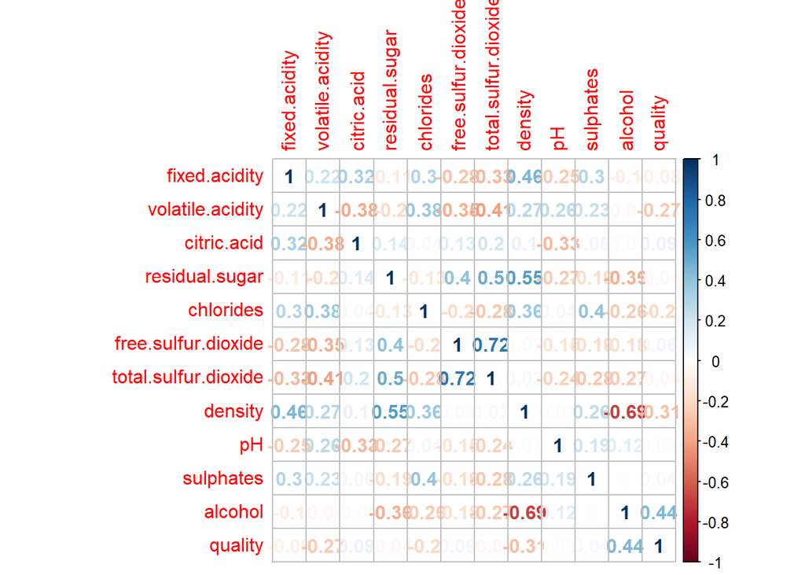

```r
#Plotting the scallertplot matrix to visualize using the corplot function of corplot libarary.
corrplot(wine_corr,method="number")
```

```r
#checking Skewness and kurtosis of dataset using the describe function of psych library.
describe(wine_redwhite)
```

```
##                      vars    n   mean    sd median trimmed   mad  min
## fixed.acidity           1 6497   7.22  1.30   7.00    7.06  0.89 3.80
## volatile.acidity        2 6497   0.34  0.16   0.29    0.32  0.12 0.08
## citric.acid             3 6497   0.32  0.15   0.31    0.32  0.10 0.00
## residual.sugar          4 6497   5.44  4.76   3.00    4.70  2.52 0.60
## chlorides               5 6497   0.06  0.04   0.05    0.05  0.02 0.01
## free.sulfur.dioxide     6 6497  30.53 17.75  29.00   29.32 17.79 1.00
## total.sulfur.dioxide    7 6497 115.74 56.52 118.00  115.92 57.82 6.00
## density                 8 6497   0.99  0.00   0.99    0.99  0.00 0.99
## pH                      9 6497   3.22  0.16   3.21    3.21  0.16 2.72
## sulphates              10 6497   0.53  0.15   0.51    0.52  0.12 0.22
## alcohol                11 6497  10.49  1.19  10.30   10.40  1.33 8.00
## quality                12 6497   5.82  0.87   6.00    5.79  1.48 3.00
##                         max  range skew kurtosis   se
## fixed.acidity         15.90  12.10 1.72     5.05 0.02
## volatile.acidity       1.58   1.50 1.49     2.82 0.00
## citric.acid            1.66   1.66 0.47     2.39 0.00
## residual.sugar        65.80  65.20 1.43     4.35 0.06
## chlorides              0.61   0.60 5.40    50.84 0.00
## free.sulfur.dioxide  289.00 288.00 1.22     7.90 0.22
## total.sulfur.dioxide 440.00 434.00 0.00    -0.37 0.70
## density                1.04   0.05 0.50     6.60 0.00
## pH                     4.01   1.29 0.39     0.37 0.00
## sulphates              2.00   1.78 1.80     8.64 0.00
## alcohol               14.90   6.90 0.57    -0.53 0.01
## quality                9.00   6.00 0.19     0.23 0.01
```

From describe function output, we observe that skewness coefficient for quality is 0.19 and kurtosis is 0.23 which shows that the distribution is approximately symmetric.

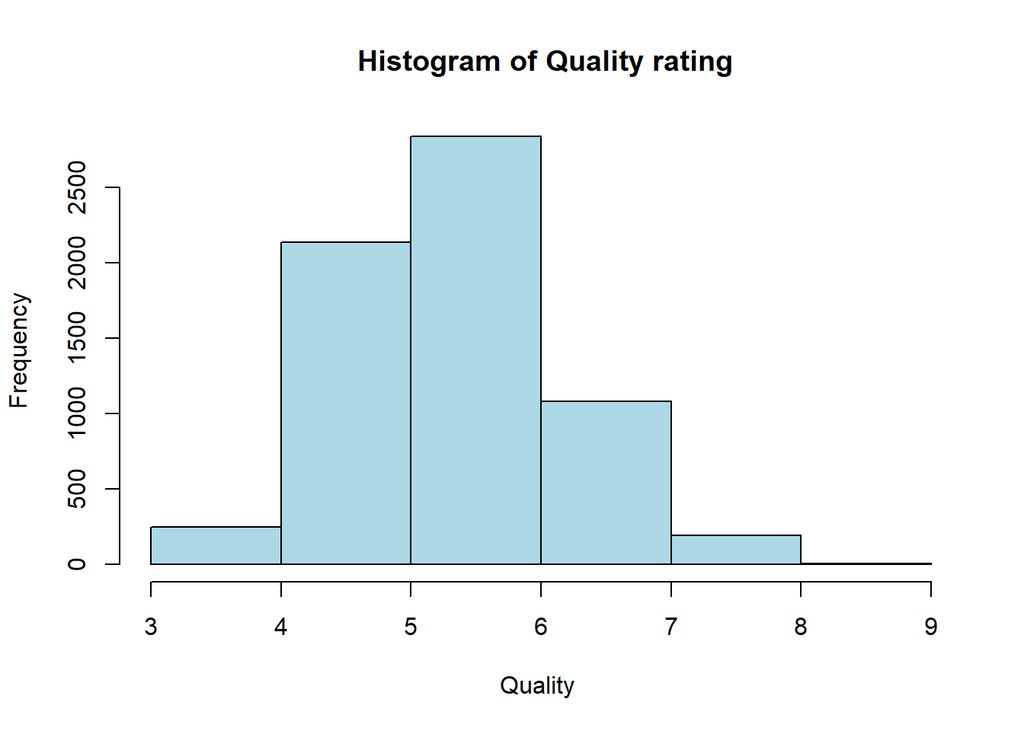

```r
#histrogram for Quality
hist_2 <- hist(wine_redwhite$quality, breaks = 5, col ="lightblue", xlab = "Quality ", main= " Histogram of Quality rating")
```

```r
table(wine_redwhite$quality) #table to get frquency of different qualities in dataset
```

```
##
##    3    4    5    6    7    8    9
##   30  216 2138 2836 1079  193    5
```

Rather than using the entire dataset as its very larges dataset This is one of the reasons we need to use training and test set separation. After we have trained our model, we should test it on fresh examples so that we can avoid problems like overfitting. We can also estimate how well our model is performing given that it is facing new inputs. Based on the performance, we can proceed on developing our system further. so i am spliting the data into a training set and a testing set. As their names imply, the training set is used to train and build the model, and then this model is tested on the testing set Sampling the data randomly using seed and sample function

```r
set.seed(1235)
wine_redwhite <- wine_redwhite[sample(nrow(wine_redwhite)),]

#Now Selecting 50% of data as sample from total number of rows of the data
split <- floor(nrow(wine_redwhite)/2)

wine_train <- wine_redwhite[0:split,] # Training Data
wine_test <- wine_redwhite[(split+1):(nrow(wine_redwhite)-1),]# Testing Data
```

First Regression Model using multiple variable Treating quality as a continuous variable, Estimating a multiple linear regression model. Creating the initial multinominal Linear Model with quality as a continuous dependent variable and Model with all other variables as predictors

```r
#
lm1 <- lm(as.numeric(quality) ~ alcohol + volatile.acidity + free.sulfur.dioxide + sulphates + total.sulfur.dioxide + density + residual.sugar+ fixed.acidity + citric.acid+ chlorides + pH, data=wine_train)

summary(lm1) #Evaluation calculates Residual standard error = 0.74, Multi R squared = 0.28, and Adj R squared = 0.28
```

```
##
## Call:
## lm(formula = as.numeric(quality) ~ alcohol + volatile.acidity +
##     free.sulfur.dioxide + sulphates + total.sulfur.dioxide +
##     density + residual.sugar + fixed.acidity + citric.acid +
##     chlorides + pH, data = wine_train)
##
## Residuals:
##     Min      1Q  Median      3Q     Max
## -3.2807 -0.4751 -0.0391  0.4639  2.6654
##
## Coefficients:
##                        Estimate Std. Error t value Pr(>|t|)
## (Intercept)           5.315e+01  1.755e+01   3.028 0.002484 **
## alcohol               2.666e-01  2.467e-02  10.809  < 2e-16 ***
## volatile.acidity     -1.292e+00  1.070e-01 -12.073  < 2e-16 ***
## free.sulfur.dioxide   6.837e-03  1.105e-03   6.189 6.81e-10 ***
## sulphates             6.632e-01  1.083e-01   6.124 1.02e-09 ***
## total.sulfur.dioxide -1.960e-03  3.993e-04  -4.910 9.58e-07 ***
## density              -5.245e+01  1.790e+01  -2.929 0.003420 **
## residual.sugar        3.597e-02  7.420e-03   4.847 1.31e-06 ***
## fixed.acidity         8.273e-02  2.258e-02   3.663 0.000253 ***
## citric.acid          -3.029e-02  1.132e-01  -0.268 0.789088
## chlorides            -1.584e-01  4.724e-01  -0.335 0.737361
## pH                    4.267e-01  1.294e-01   3.297 0.000987 ***
## ---
## Signif. codes:  0 '***' 0.001 '**' 0.01 '*' 0.05 '.' 0.1 ' ' 1
##
## Residual standard error: 0.7364 on 3236 degrees of freedom
## Multiple R-squared:  0.283,  Adjusted R-squared:  0.2805
## F-statistic: 116.1 on 11 and 3236 DF,  p-value: < 2.2e-16
```

```r
confint(lm1, level=0.95) # checking the model on 95% CI
```

```
##                              2.5 %        97.5 %
## (Intercept)           18.730035583  87.568370295
## alcohol                0.218273317   0.315011040
## volatile.acidity      -1.501791650  -1.082139157
## free.sulfur.dioxide    0.004671041   0.009002888
## sulphates              0.450886635   0.875599455
## total.sulfur.dioxide  -0.002743486  -0.001177562
## density              -87.550186497 -17.343374106
## residual.sugar         0.021416824   0.050513314
## fixed.acidity          0.038444681   0.127008502
## citric.acid           -0.252309480   0.191725317
## chlorides             -1.084743426   0.767854626
## pH                     0.172946115   0.680371329
```

ANOVA’s null hypothesis is whether group mean values of the dependent variable are not significantly different, while an alternative hypothesis is just that at least one of the factor level forms a group of observations which mean value is different from overall mean. So using anova on this multiple regression helps us indentifying the variable which are not significant for the model.

```r
anova(lm1) #Anova evaluation finds Citric Acid, Chlorides, and Fixed acidity are not significant in this model.
```

```
## Analysis of Variance Table
##
## Response: as.numeric(quality)
##                        Df  Sum Sq Mean Sq  F value    Pr(>F)
## alcohol                 1  463.93  463.93 855.6230 < 2.2e-16 ***
## volatile.acidity        1  163.64  163.64 301.7982 < 2.2e-16 ***
## free.sulfur.dioxide     1   10.28   10.28  18.9631 1.374e-05 ***
## sulphates               1   24.41   24.41  45.0181 2.295e-11 ***
## total.sulfur.dioxide    1    8.64    8.64  15.9383 6.689e-05 ***
## density                 1    7.40    7.40  13.6534 0.0002235 ***
## residual.sugar          1    5.54    5.54  10.2148 0.0014066 **
## fixed.acidity           1    1.92    1.92   3.5405 0.0599771 .
## citric.acid             1    0.22    0.22   0.4100 0.5220350
## chlorides               1    0.58    0.58   1.0667 0.3017793
## pH                      1    5.89    5.89  10.8717 0.0009870 ***
## Residuals            3236 1754.61    0.54
## ---
## Signif. codes:  0 '***' 0.001 '**' 0.01 '*' 0.05 '.' 0.1 ' ' 1
```

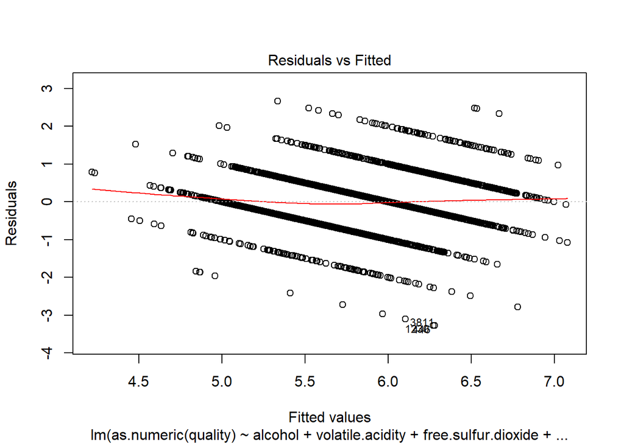

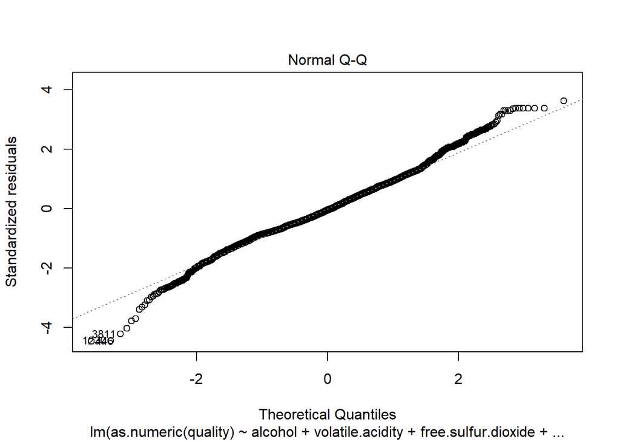

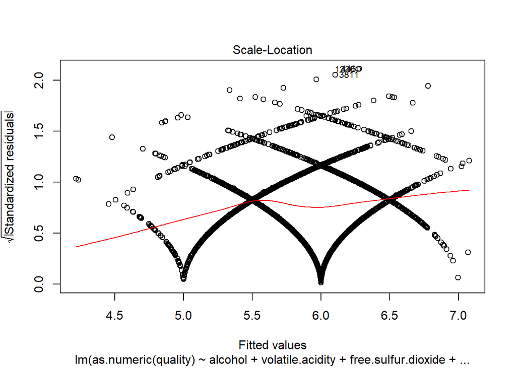

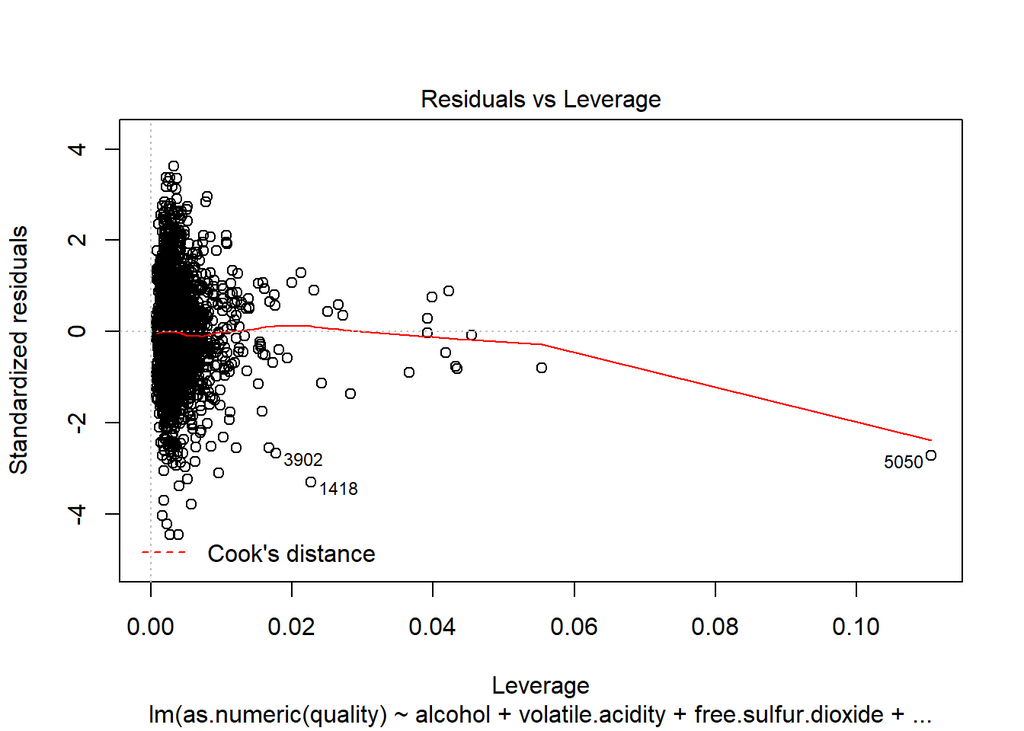

```r
#ploting from model.
plot(lm1)
```

```r
#Testing the prediction model
prediction1 <- predict(lm1, newdata = wine_test)
```

testing the data with fresh value to prdict the quailty of wine

```r
#testing the data with fresh value to prdict the quailty of wine
data123 <- data.frame(alcohol=10, volatile.acidity = .28, free.sulfur.dioxide = 34, sulphates =.48, total.sulfur.dioxide =120, density =.9856, residual.sugar=9, fixed.acidity = 7.2, citric.acid =.28, chlorides = .045, pH =3.02)
predict(lm1, data123)
```

```
##        1
## 6.270093
```

Graphical Analysis of Linear Regression assumption Assumption 1- residuals plot can be used to assess the assumption that the variables have a linear relationship

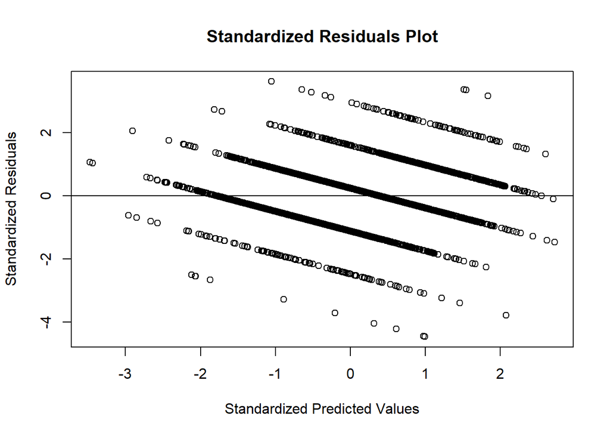

```r
unstandardizedPredicted <- predict(lm1) # predicting the unstandardize quailty value using the above train model
unstandardizedResiduals <- resid(lm1) # calcuating the unstandardardize residuals values.
#calculating standardized values using the formula.
standardizedPredicted <- (unstandardizedPredicted - mean(unstandardizedPredicted)) / sd(unstandardizedPredicted)
standardizedResiduals <- (unstandardizedResiduals - mean(unstandardizedResiduals)) / sd(unstandardizedResiduals)
#creating standardized residuals plot
plot(standardizedPredicted, standardizedResiduals, main = "Standardized Residuals Plot", xlab = "Standardized Predicted Values", ylab = "Standardized Residuals")
#adding horizontal line to above plot
abline(0,0)
```

Explanation of above Residual plot- values that are close to the horizontal line are predicted well. The points above the line are underpredicted and the ones below the line are overpredicted. The linearity assumption is supported to the extent that the amount of points scattered above and below the line is equal.

Residual histogram- using a histogram we may assess the assumption that the residuals are normally distributed

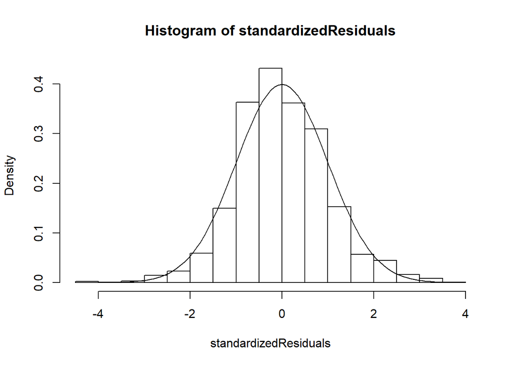

```r
hist(standardizedResiduals, freq = FALSE)#creating residuals histogram

curve(dnorm, add = TRUE)
```

adding normal curve. it shows that Points in the residual plot are dispersed randomly or normally distributed.

I am creating one more Linear Model 2 using only Volatile Acidity, Alcohol, free suphur dioxide and Sulphates as independent variables as linear model one was not significant enough

```r
lm2 <-lm(as.numeric(quality)~ alcohol + free.sulfur.dioxide + sulphates + volatile.acidity, data=wine_train)

summary(lm2)#
```

```
##
## Call:
## lm(formula = as.numeric(quality) ~ alcohol + free.sulfur.dioxide +
##     sulphates + volatile.acidity, data = wine_train)
##
## Residuals:
##     Min      1Q  Median      3Q     Max
## -3.2730 -0.4754 -0.0287  0.4570  2.5672
##
## Coefficients:
##                       Estimate Std. Error t value Pr(>|t|)
## (Intercept)          2.4272306  0.1434983  16.915  < 2e-16 ***
## alcohol              0.3232049  0.0112053  28.844  < 2e-16 ***
## free.sulfur.dioxide  0.0042448  0.0008299   5.115 3.33e-07 ***
## sulphates            0.5978010  0.0897634   6.660 3.21e-11 ***
## volatile.acidity    -1.3019892  0.0848539 -15.344  < 2e-16 ***
## ---
## Signif. codes:  0 '***' 0.001 '**' 0.01 '*' 0.05 '.' 0.1 ' ' 1
##
## Residual standard error: 0.7419 on 3243 degrees of freedom
## Multiple R-squared:  0.2706, Adjusted R-squared:  0.2697
## F-statistic: 300.8 on 4 and 3243 DF,  p-value: < 2.2e-16
```

```r
confint(lm2, level=0.95) #
```

```
##                            2.5 %      97.5 %
## (Intercept)          2.145874042  2.70858725
## alcohol              0.301234711  0.34517513
## free.sulfur.dioxide  0.002617525  0.00587201
## sulphates            0.421802302  0.77379964
## volatile.acidity    -1.468361820 -1.13561661
```

```r
anova(lm2) #
```

```
## Analysis of Variance Table
##
## Response: as.numeric(quality)
##                       Df  Sum Sq Mean Sq F value    Pr(>F)
## alcohol                1  463.93  463.93  842.97 < 2.2e-16 ***
## free.sulfur.dioxide    1   59.25   59.25  107.65 < 2.2e-16 ***
## sulphates              1    9.51    9.51   17.28 3.309e-05 ***
## volatile.acidity       1  129.57  129.57  235.44 < 2.2e-16 ***
## Residuals           3243 1784.81    0.55
## ---
## Signif. codes:  0 '***' 0.001 '**' 0.01 '*' 0.05 '.' 0.1 ' ' 1
```

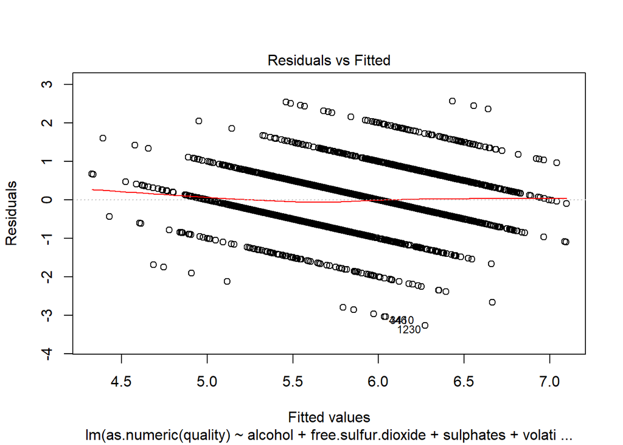

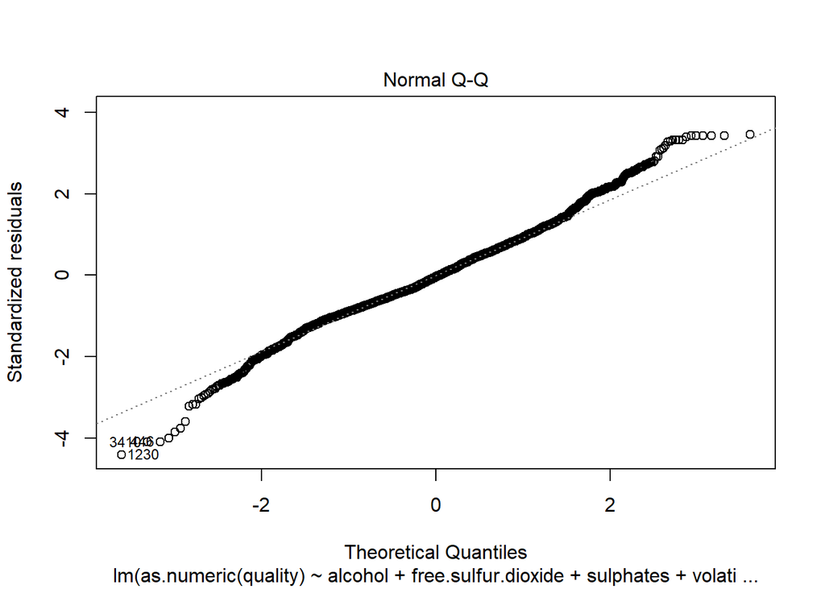

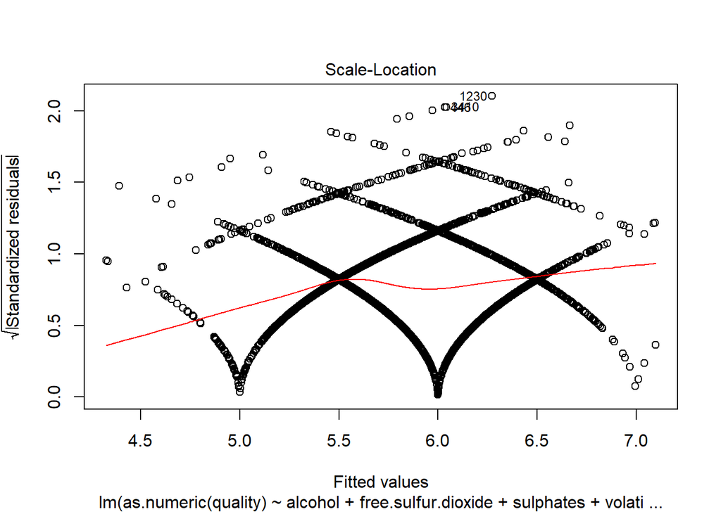

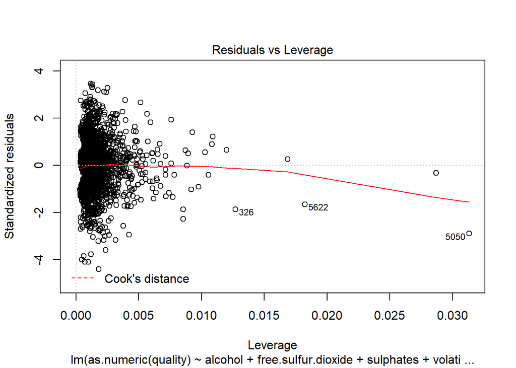

```r
plot(lm2)
```

predicting the quality of wine with second model with fresh values of predictors

```r
#Testing the prediction model
prediction2 <- predict(lm2, newdata = wine_test)
#predicting the quality of wine with second model with fresh values of predictors
data1234 <- data.frame(alcohol=10, free.sulfur.dioxide = 34, sulphates =.48, volatile.acidity =.19)
predict(lm2,data1234)
```

```
##        1
## 5.843168
```

Root mean square Error of linear model

```r
#Root mean square Error of linear model
rmse <- function(error)
{
  sqrt(mean(error^2))
}

error <- lm2$residuals  # same as data$Y - predictedY
predictionRMSE <- rmse(error)
predictionRMSE
```

```
## [1] 0.7412893
```

# K means

# —————————————

the technique used for clustering is the K-means and the description of the dataset for this analysis is Online Shoppers Intention that was obtained in the next link (https://archive.ics.uci.edu/ml/datasets.html)

## Description of dataset

The dataset consists of 10 numerical and 8 categorical attributes. “Administrative”, “Administrative Duration”, “Informational”, “Informational Duration”, “Product Related” and “Product Related Duration” represent the number of different types of pages visited by the visitor in that session and total time spent in each of these page categories. The values of these features are derived from the URL information of the pages visited by the user and updated in real time when a user takes an action, e.g. moving from one page to another. The “Bounce Rate”, “Exit Rate” and “Page Value” features represent the metrics measured by “Google Analytics” for each page in the e-commerce site. The value of “Bounce Rate” feature for a web page refers to the percentage of visitors who enter the site from that page and then leave (“bounce”) without triggering any other requests to the analytics server during that session. The value of “Exit Rate” feature for a specific web page is calculated as for all pageviews to the page, the percentage that were the last in the session. The “Page Value” feature represents the average value for a web page that a user visited before completing an e-commerce transaction. The “Special Day” feature indicates the closeness of the site visiting time to a specific special day (e.g. Mother’s Day, Valentine’s Day) in which the sessions are more likely to be finalized with transaction. The value of this attribute is determined by considering the dynamics of e-commerce such as the duration between the order date and delivery date. For example, for Valentina’s day, this value takes a nonzero value between February 2 and February 12, zero before and after this date unless it is close to another special day, and its maximum value of 1 on February 8. The dataset also includes operating system, browser, region, traffic type, visitor type as returning or new visitor, a Boolean value indicating whether the date of the visit is weekend, and month of the year.

# FIRST CLUSTER ANALYSIS

Due to the heuristic nature of k-means, making any changes could have a different results, for that reason, we try a cluster analysis more than once to test the robustness of our findings

```r
#exploring and preparing the data
str(online_intention)
```

```
## 'data.frame':    12330 obs. of  18 variables:
##  $ Administrative         : int  0 0 0 0 0 0 0 1 0 0 ...
##  $ Administrative_Duration: num  0 0 0 0 0 0 0 0 0 0 ...
##  $ Informational          : int  0 0 0 0 0 0 0 0 0 0 ...
##  $ Informational_Duration : num  0 0 0 0 0 0 0 0 0 0 ...
##  $ ProductRelated         : int  1 2 1 2 10 19 1 0 2 3 ...
##  $ ProductRelated_Duration: num  0 64 0 2.67 627.5 ...
##  $ BounceRates            : num  0.2 0 0.2 0.05 0.02 ...
##  $ ExitRates              : num  0.2 0.1 0.2 0.14 0.05 ...
##  $ PageValues             : num  0 0 0 0 0 0 0 0 0 0 ...
##  $ SpecialDay             : num  0 0 0 0 0 0 0.4 0 0.8 0.4 ...
##  $ Month                  : Factor w/ 10 levels "Aug","Dec","Feb",..: 3 3 3 3 3 3 3 3 3 3 ...
##  $ OperatingSystems       : int  1 2 4 3 3 2 2 1 2 2 ...
##  $ Browser                : int  1 2 1 2 3 2 4 2 2 4 ...
##  $ Region                 : int  1 1 9 2 1 1 3 1 2 1 ...
##  $ TrafficType            : int  1 2 3 4 4 3 3 5 3 2 ...
##  $ VisitorType            : Factor w/ 3 levels "New_Visitor",..: 3 3 3 3 3 3 3 3 3 3 ...
##  $ Weekend                : logi  FALSE FALSE FALSE FALSE TRUE FALSE ...
##  $ Revenue                : logi  FALSE FALSE FALSE FALSE FALSE FALSE ...
```

```r
summary(online_intention)
```

```
##  Administrative   Administrative_Duration Informational
##  Min.   : 0.000   Min.   :   0.00         Min.   : 0.0000
##  1st Qu.: 0.000   1st Qu.:   0.00         1st Qu.: 0.0000
##  Median : 1.000   Median :   7.50         Median : 0.0000
##  Mean   : 2.315   Mean   :  80.82         Mean   : 0.5036
##  3rd Qu.: 4.000   3rd Qu.:  93.26         3rd Qu.: 0.0000
##  Max.   :27.000   Max.   :3398.75         Max.   :24.0000
##
##  Informational_Duration ProductRelated   ProductRelated_Duration
##  Min.   :   0.00        Min.   :  0.00   Min.   :    0.0
##  1st Qu.:   0.00        1st Qu.:  7.00   1st Qu.:  184.1
##  Median :   0.00        Median : 18.00   Median :  598.9
##  Mean   :  34.47        Mean   : 31.73   Mean   : 1194.8
##  3rd Qu.:   0.00        3rd Qu.: 38.00   3rd Qu.: 1464.2
##  Max.   :2549.38        Max.   :705.00   Max.   :63973.5
##
##   BounceRates         ExitRates         PageValues        SpecialDay
##  Min.   :0.000000   Min.   :0.00000   Min.   :  0.000   Min.   :0.00000
##  1st Qu.:0.000000   1st Qu.:0.01429   1st Qu.:  0.000   1st Qu.:0.00000
##  Median :0.003112   Median :0.02516   Median :  0.000   Median :0.00000
##  Mean   :0.022191   Mean   :0.04307   Mean   :  5.889   Mean   :0.06143
##  3rd Qu.:0.016813   3rd Qu.:0.05000   3rd Qu.:  0.000   3rd Qu.:0.00000
##  Max.   :0.200000   Max.   :0.20000   Max.   :361.764   Max.   :1.00000
##
##      Month      OperatingSystems    Browser           Region
##  May    :3364   Min.   :1.000    Min.   : 1.000   Min.   :1.000
##  Nov    :2998   1st Qu.:2.000    1st Qu.: 2.000   1st Qu.:1.000
##  Mar    :1907   Median :2.000    Median : 2.000   Median :3.000
##  Dec    :1727   Mean   :2.124    Mean   : 2.357   Mean   :3.147
##  Oct    : 549   3rd Qu.:3.000    3rd Qu.: 2.000   3rd Qu.:4.000
##  Sep    : 448   Max.   :8.000    Max.   :13.000   Max.   :9.000
##  (Other):1337
##   TrafficType               VisitorType     Weekend         Revenue
##  Min.   : 1.00   New_Visitor      : 1694   Mode :logical   Mode :logical
##  1st Qu.: 2.00   Other            :   85   FALSE:9462      FALSE:10422
##  Median : 2.00   Returning_Visitor:10551   TRUE :2868      TRUE :1908
##  Mean   : 4.07
##  3rd Qu.: 4.00
##  Max.   :20.00
##
```

as we can see there is not NA values but there are four categorical values - Month, VisitorType, Weekend and Revenue. DUMMY CODING FOR CATEGORICAL VARIABLES

```r
#To apply   z-score standardization to  the interests   data    frame,
#we can use the scale() function    with    lapply()
intention_z <-  as.data.frame(lapply(intention, scale))
#checking that the standarization is correct with the 5th columns
summary(intention_z[1:5])
```

```
##  Administrative    Administrative_Duration Informational
##  Min.   :-0.6970   Min.   :-0.45717        Min.   :-0.3965
##  1st Qu.:-0.6970   1st Qu.:-0.45717        1st Qu.:-0.3965
##  Median :-0.3959   Median :-0.41475        Median :-0.3965
##  Mean   : 0.0000   Mean   : 0.00000        Mean   : 0.0000
##  3rd Qu.: 0.5072   3rd Qu.: 0.07036        3rd Qu.:-0.3965
##  Max.   : 7.4312   Max.   :18.76880        Max.   :18.4988
##  Informational_Duration ProductRelated
##  Min.   :-0.2449        Min.   :-0.7135
##  1st Qu.:-0.2449        1st Qu.:-0.5561
##  Median :-0.2449        Median :-0.3087
##  Mean   : 0.0000        Mean   : 0.0000
##  3rd Qu.:-0.2449        3rd Qu.: 0.1409
##  Max.   :17.8680        Max.   :15.1380
```

```r
#All variables are numerical for the clustering analysis
#this second subset is for SECOND CLUSTER ANALYSIS when using any categorical variable
intention_z2 <- intention_z[c(-11,-16,-17,-18,-19)]
```

because there is not an exactly idea how many cluster should be we use the A technique known as the elbow method.

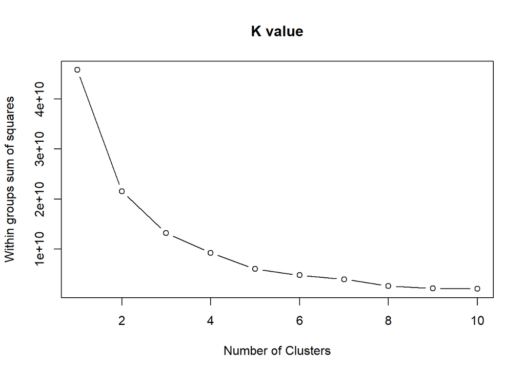

```r
wss <- (nrow(intention)-1)*sum(apply(intention,2,var))
for (i in 2:10) {
  wss[i] <- sum(kmeans(intention,
                       centers=i)$withinss)
}
plot(1:10, wss, type="b", main= "K value", xlab="Number of Clusters",
     ylab="Within groups sum of squares")
```

the result of the elbow method looks that the best k value for the analysis is 3 or 4. However, we are using the values of K = 2, 3 and 4 in order to obtain more information about clustering. Creating a function to plot the clusters

```r
#PLOT CLUSTERS FUNCTION
#in order to plot the cluster, using different variables we apply a function
#m = x-axis - using the column on online_intention$ + any column that would like
#n = y-axis - using the column on online_intention$ + any column that would like
#o = colour of graphs - in this case we are using a cluster column as colour
#p = number of the graphs -  include on the title
funct_plot <- function(m,n,o,p){
  legend1 <- table(o)
  legend_num <- (names(legend1))
  plot(x = m, y = n, main = paste("Clusters Graph",p), xlab = names(m),
       ylab = names(n), col=o)

  legend("bottomright", legend = names(legend1), fill =(legend_num), title = "Clusters",
         col=(legend_num),lty=1:2, cex=0.8,box.lty=0)
}
```

## 2 clusters (all the columns)

```r
#divide online shoppers intention   into    two clusters
intention_clusters  <-  kmeans(intention_z, 2)
# exploring the clusters - size, centroids
intention_clusters$size
```

```
## [1] 7976 4354
```

```r
intention_clusters$centers
```

```
##   Administrative Administrative_Duration Informational
## 1     -0.3857686              -0.2927080    -0.2730753
## 2      0.7066813               0.5362056     0.5002409
##   Informational_Duration ProductRelated ProductRelated_Duration
## 1             -0.2038680     -0.2681431              -0.2493972
## 2              0.3734614      0.4912057               0.4568654
##   BounceRates  ExitRates PageValues SpecialDay      Month OperatingSystems
## 1   0.2021292  0.2774081 -0.2349839  0.1181515 -0.1647093       0.01085806
## 2  -0.3702761 -0.5081781  0.4304621 -0.2164392  0.3017275      -0.01989064
##        Browser        Region TrafficType Return_visitor New_visitor
## 1  0.009695424 -7.185975e-05  0.03298512      0.3777787  -0.3852320
## 2 -0.017760842  1.316384e-04 -0.06042474     -0.6920448   0.7056983
##    no_weekend no_renevue
## 1  0.05645365  0.3176186
## 2 -0.10341623 -0.5818388
```

```r
#get the clusters means
aggregate(intention, by=list(intention_clusters$cluster), FUN = mean)
```

```
##   Group.1 Administrative Administrative_Duration Informational
## 1       1       1.033726                29.07395     0.1567202
## 2       2       4.662609               175.60856     1.1389527
##   Informational_Duration ProductRelated ProductRelated_Duration
## 1               5.778126       19.80567                717.4825
## 2              87.036824       53.57809               2069.0356
##   BounceRates  ExitRates PageValues SpecialDay    Month OperatingSystems
## 1 0.031992285 0.05655387   1.525974 0.08492979 7.093154         2.133902
## 2 0.004237311 0.01837710  13.882266 0.01837391 8.675701         2.105880
##    Browser   Region TrafficType Return_visitor New_visitor no_weekend
## 1 2.373746 3.147192    4.202357      0.9884654 0.004764293  0.7912487
## 2 2.326596 3.147680    3.826367      0.6125402 0.380339917  0.7237023
##   no_renevue
## 1  0.9601304
## 2  0.6348186
```

```r
#append cluster assignment
online_intention <- data.frame(online_intention, intention_clusters$cluster)
```

the above information is some of the values that was created by the kmeans algorithm such as the size for each cluster and the centers that giving an idea how are the clusters and what are the distance among them. the next graphs show the first cluster with different variables in some of them there is not easy to identify the clusters, although these will be the point of comparison between other cluster.

the following plots are usisng some of the variables in order to show the clusters in a graph.

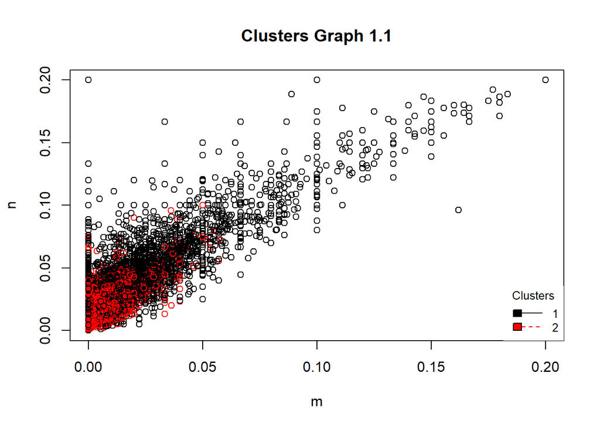

```r
funct_plot(online_intention$BounceRates, online_intention$ExitRates,
          intention_clusters$cluster, 1.1) # graph 1
```

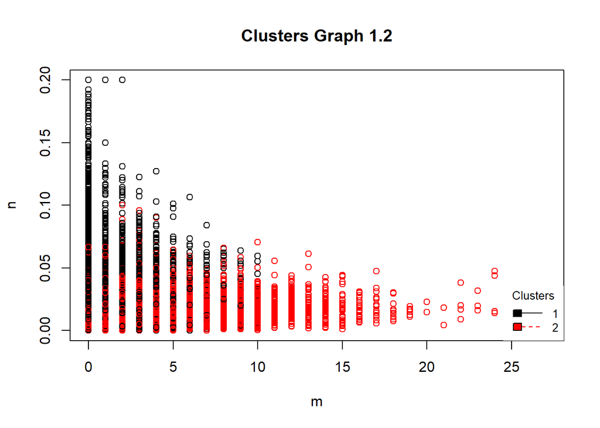

```r
funct_plot(online_intention$Administrative, online_intention$ExitRates,
           intention_clusters$cluster, 1.2)# graph 2
```

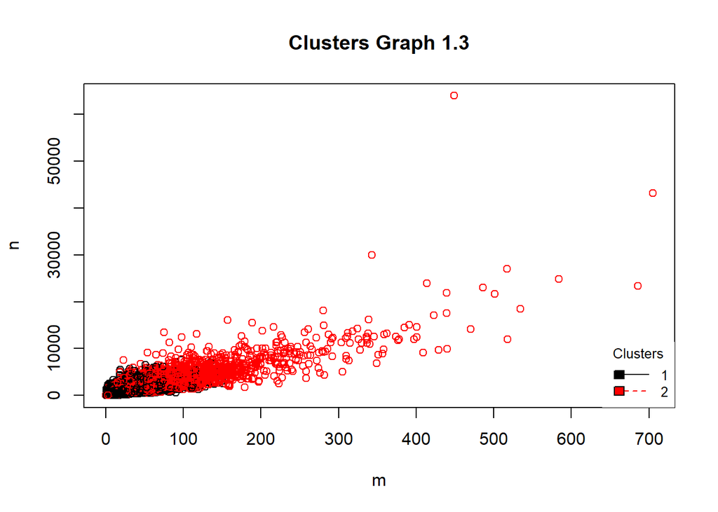

```r
funct_plot(online_intention$ProductRelated, online_intention$ProductRelated_Duration,
           intention_clusters$cluster, 1.3)# graph 3
```

we could see in the graphs, there are some variables that do not have much influence in how were making the clusters. also wue can see that there is one group in the top, the biggest one and inside of this there is another cluster which could be a Traditional Hierarchical Clustering.

## 3 CLUSTERs (all the columns)

we will apply the analysis with 3 clusters

```r
#also, we can include in the kmeans function more criterials as following.
#for instances, centers and nstart
#we are creating 3 clusters
intention_clusters2 <-  kmeans(intention_z, centers = 3, nstart = 25)
intention_clusters2$size
```

```
## [1] 1739 8722 1869
```

```r
intention_clusters2$centers
```

```
##   Administrative Administrative_Duration Informational
## 1     0.05797993              0.03843439    -0.1592292
## 2    -0.32078170             -0.25443432    -0.2552850
## 3     1.44303417              1.15159910     1.3394837
##   Informational_Duration ProductRelated ProductRelated_Duration
## 1             -0.1300551     -0.3163319              -0.2992922
## 2             -0.1975264     -0.2318698              -0.2162986
## 3              1.0427989      1.3763883               1.2878683
##   BounceRates  ExitRates PageValues  SpecialDay      Month
## 1  -0.3519350 -0.4586048  0.2928345 -0.21167575  0.2644330
## 2   0.1403039  0.1944284 -0.1130372  0.07955825 -0.1245129
## 3  -0.3272958 -0.4806264  0.2550408 -0.17431940  0.3350201
##   OperatingSystems      Browser       Region TrafficType Return_visitor
## 1      0.062691255  0.121891231  0.115347555  0.04700002     -2.4352370
## 2     -0.008754348 -0.008251773 -0.003929508  0.01544021      0.4017947
## 3     -0.017477085 -0.074904699 -0.088986747 -0.11578521      0.3908098
##   New_visitor  no_weekend no_renevue
## 1   2.4137503 -0.10412175 -0.2637701
## 2  -0.3990708  0.02951516  0.1511100
## 3  -0.3835294 -0.04085794 -0.4597566
```

```r
#get the clusters means
aggregate(intention, by=list(intention_clusters2$cluster), FUN = mean)
```

```
##   Group.1 Administrative Administrative_Duration Informational
## 1       1       2.507763                87.61301     0.3013226
## 2       2       1.249599                35.83994     0.1793167
## 3       3       7.108614               284.39727     2.2049224
##   Informational_Duration ProductRelated ProductRelated_Duration
## 1              16.167239       17.66245                621.9999
## 2               6.670696       21.41894                780.8222
## 3             181.245601       92.94703               3659.3003
##   BounceRates  ExitRates PageValues SpecialDay    Month OperatingSystems
## 1 0.005126642 0.02078619  11.326736 0.01932145 8.549166         2.181139
## 2 0.028994483 0.05252135   3.790334 0.07725292 7.229535         2.116028
## 3 0.006321354 0.01971602  10.624966 0.02675227 8.788657         2.108079
##    Browser   Region TrafficType Return_visitor New_visitor no_weekend
## 1 2.566417 3.424382    4.258769      0.0000000 0.968372628  0.7234043
## 2 2.342926 3.137927    4.131736      0.9969044 0.000000000  0.7798670
## 3 2.228464 2.933654    3.603531      0.9930444 0.005350455  0.7501338
##   no_renevue
## 1  0.7498562
## 2  0.8999083
## 3  0.6789727
```

```r
#append cluster assignment
online_intention <- data.frame(online_intention, intention_clusters2$cluster)
```

as previuos analysis, these are the calues of the cluster such as the size for each cluster and the centers that giving an idea how are the cluster and what is the distance among them.

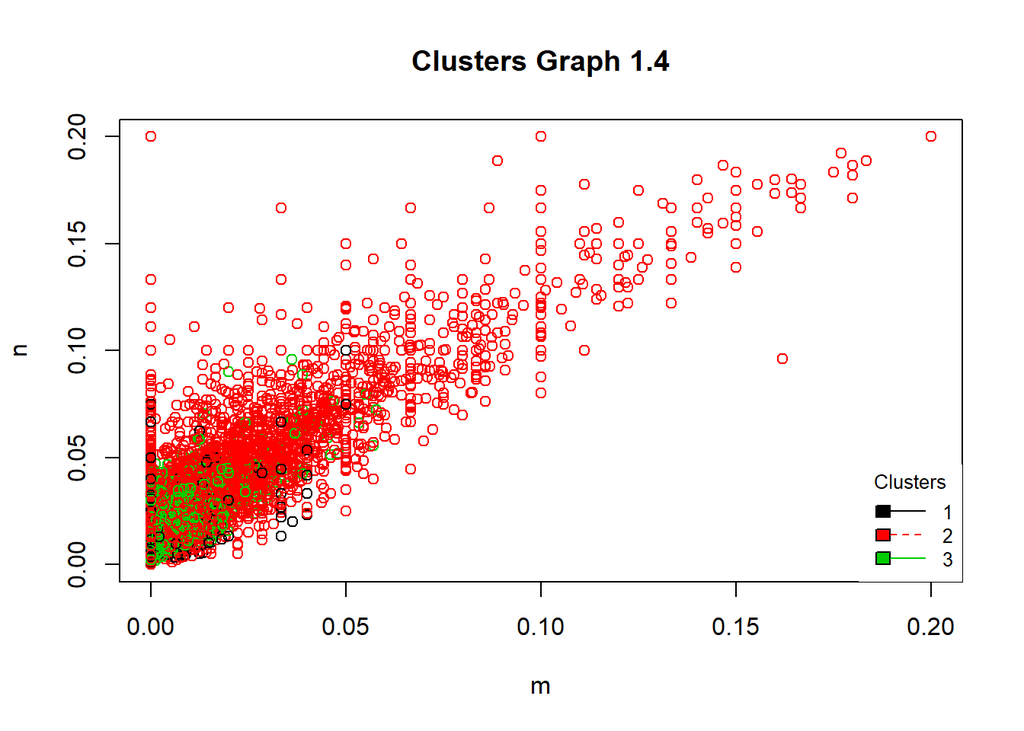

```r
#PLOTS
funct_plot(online_intention$BounceRates, online_intention$ExitRates,
           intention_clusters2$cluster, 1.4) # graph 4
```

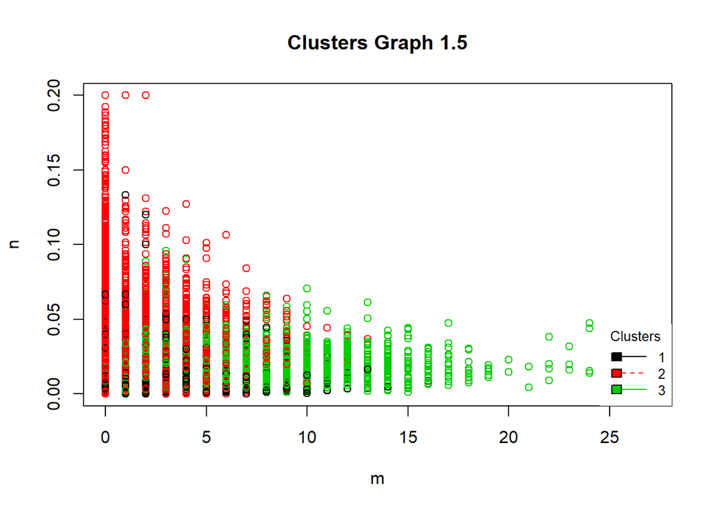

```r
funct_plot(online_intention$Administrative, online_intention$ExitRates,
           intention_clusters2$cluster, 1.5)# graph 5
```

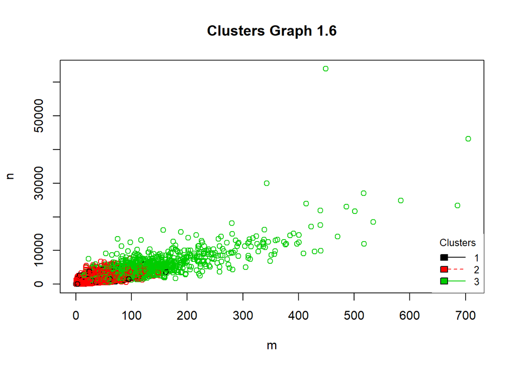

```r
funct_plot(online_intention$ProductRelated, online_intention$ProductRelated_Duration,
           intention_clusters2$cluster, 1.6)# graph 6
```

## 4 CLUSTERs (all the columns)

we will apply the analysis with 4 clusters

```r
#we are creating 4 clusters
intention_clusters3 <-  kmeans(intention_z, 4)
# exploring the clusters - size, centroids
intention_clusters3$size
```

```
## [1] 1706 1025 1548 8051
```

```r
intention_clusters3$centers
```

```
##   Administrative Administrative_Duration Informational
## 1     0.07240674              0.04790677    -0.1546402
## 2    -0.68433558             -0.44934572    -0.3872446
## 3     1.52468629              1.25197343     1.5677309
## 4    -0.22137577             -0.19366594    -0.2193647
##   Informational_Duration ProductRelated ProductRelated_Duration
## 1             -0.1278332     -0.3095462              -0.2932142
## 2             -0.2444894     -0.6459188              -0.5953210
## 3              1.2611797      1.5500895               1.4590864
## 4             -0.1842779     -0.1502156              -0.1426206
##   BounceRates  ExitRates  PageValues  SpecialDay       Month
## 1  -0.4189012 -0.5217541  0.30463398 -0.21156493  0.25892568
## 2   3.0256065  2.8519143 -0.31716498  0.24639193 -0.26175250
## 3  -0.3246925 -0.4806345  0.23486470 -0.17565908  0.34685515
## 4  -0.2340054 -0.1601140 -0.06933077  0.04723616 -0.08823285
##   OperatingSystems     Browser        Region TrafficType Return_visitor
## 1       0.06139042  0.13134340  0.1173012710  0.04736982     -2.4352370
## 2       0.07589417 -0.02557874 -0.0369869634  0.24981200      0.2856650
## 3      -0.01202359 -0.07252086 -0.1097785577 -0.11213673      0.3867052
## 4      -0.02035910 -0.01063114  0.0009604865 -0.02028103      0.4053022
##   New_visitor  no_weekend  no_renevue
## 1   2.4187837 -0.10846090 -0.27714858
## 2  -0.3168893  0.16491161  0.41706455
## 3  -0.3803066 -0.05340613 -0.45448713
## 4  -0.3990708  0.01225594  0.09301582
```

```r
#get the clusters means
aggregate(intention, by=list(intention_clusters2$cluster), FUN = mean)
```

```
##   Group.1 Administrative Administrative_Duration Informational
## 1       1       2.507763                87.61301     0.3013226
## 2       2       1.249599                35.83994     0.1793167
## 3       3       7.108614               284.39727     2.2049224
##   Informational_Duration ProductRelated ProductRelated_Duration
## 1              16.167239       17.66245                621.9999
## 2               6.670696       21.41894                780.8222
## 3             181.245601       92.94703               3659.3003
##   BounceRates  ExitRates PageValues SpecialDay    Month OperatingSystems
## 1 0.005126642 0.02078619  11.326736 0.01932145 8.549166         2.181139
## 2 0.028994483 0.05252135   3.790334 0.07725292 7.229535         2.116028
## 3 0.006321354 0.01971602  10.624966 0.02675227 8.788657         2.108079
##    Browser   Region TrafficType Return_visitor New_visitor no_weekend
## 1 2.566417 3.424382    4.258769      0.0000000 0.968372628  0.7234043
## 2 2.342926 3.137927    4.131736      0.9969044 0.000000000  0.7798670
## 3 2.228464 2.933654    3.603531      0.9930444 0.005350455  0.7501338
##   no_renevue
## 1  0.7498562
## 2  0.8999083
## 3  0.6789727
```

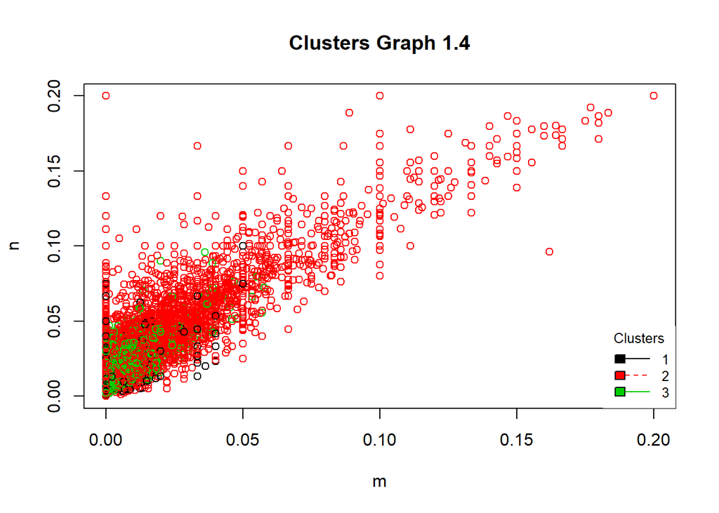

```r
#append cluster assignment
online_intention <- data.frame(online_intention, intention_clusters2$cluster)
#PLOTS
funct_plot(online_intention$BounceRates, online_intention$ExitRates,
           intention_clusters2$cluster, 1.4) # graph 4
```

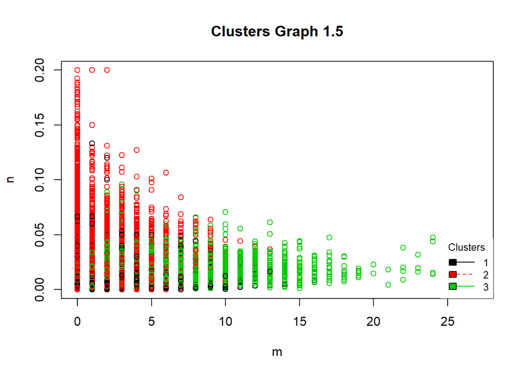

```r
funct_plot(online_intention$Administrative, online_intention$ExitRates,
           intention_clusters2$cluster, 1.5)# graph 5
```

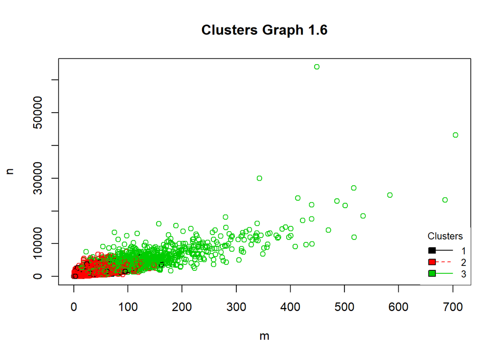

```r
funct_plot(online_intention$ProductRelated, online_intention$ProductRelated_Duration,
           intention_clusters2$cluster, 1.6)# graph 6
```

# SECOND CLUSTER ANALYSIS

## 2 clusters (without MOnths, VisitorType, Weekend and Revenue columns(categorical))

```r
#divide online shoppers intention   into    two clusters
intention_clusters4 <-  kmeans(intention_z2,    2)
# exploring the clusters - size, centroids
intention_clusters4$size
```

```
## [1] 11220  1110
```

```r
intention_clusters4$centers
```

```
##   Administrative Administrative_Duration Informational
## 1     0.06712655              0.04423334    0.03802927
## 2    -0.67852242             -0.44711535   -0.38440400
##   Informational_Duration ProductRelated ProductRelated_Duration
## 1             0.02416856     0.06305005              0.05824617
## 2            -0.24429842    -0.63731671             -0.58875859
##   BounceRates  ExitRates  PageValues  SpecialDay OperatingSystems
## 1  -0.2839326 -0.2711815  0.03137728 -0.02868272     -0.007467219
## 2   2.8700210  2.7411316 -0.31716498  0.28992800      0.075479458
##       Browser       Region TrafficType
## 1  0.00245887  0.004548908 -0.02590117
## 2 -0.02485453 -0.045980854  0.26181187
```

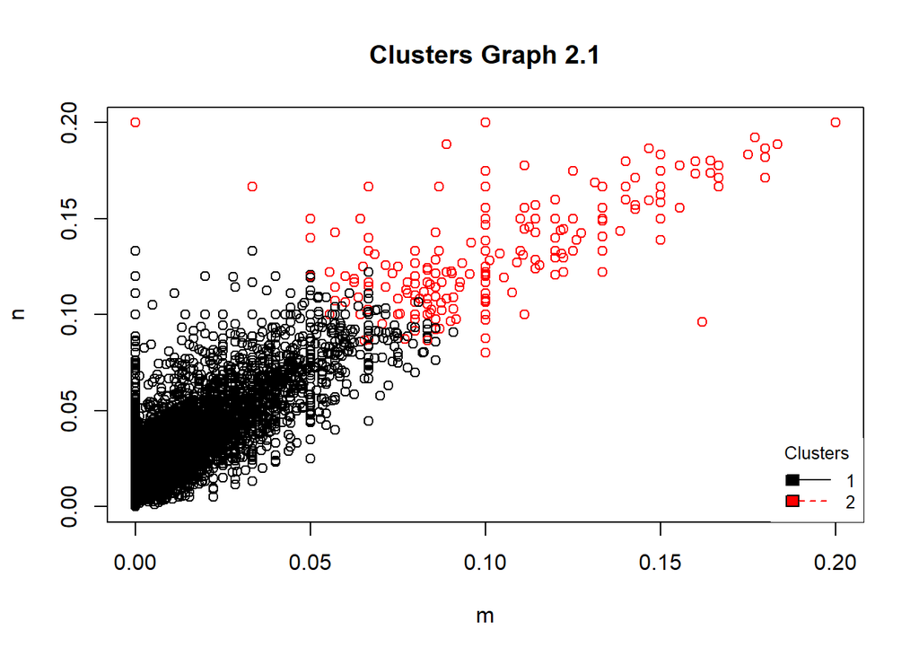

```r
#improving model performance
funct_plot(online_intention$BounceRates, online_intention$ExitRates,
           intention_clusters4$cluster, 2.1) # graph 10
```

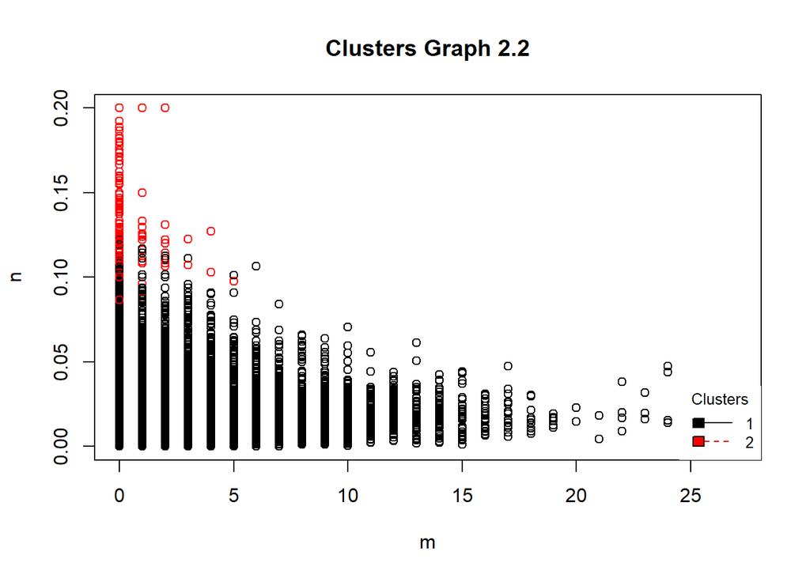

```r
funct_plot(online_intention$Administrative, online_intention$ExitRates,
           intention_clusters4$cluster, 2.2)# graph 11
```

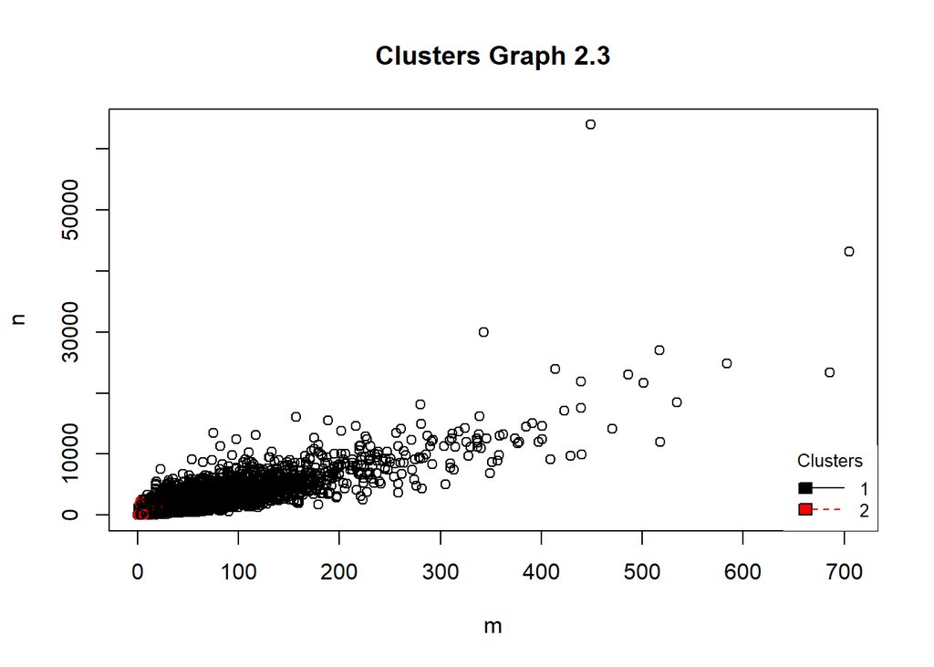

```r
funct_plot(online_intention$ProductRelated, online_intention$ProductRelated_Duration,
           intention_clusters4$cluster, 2.3)# graph 12
```

```r
#get the clusters means
aggregate(intention, by=list(intention_clusters4$cluster), FUN = mean)
```

```
##   Group.1 Administrative Administrative_Duration Informational
## 1       1     2.53814617               88.638140    0.55187166
## 2       2     0.06126126                1.777958    0.01531532
##   Informational_Duration ProductRelated ProductRelated_Duration
## 1            37.87410574      34.535651              1306.21013
## 2             0.08756757       3.386486                68.05699
##   BounceRates  ExitRates PageValues SpecialDay    Month OperatingSystems
## 1 0.008423967 0.02989432   6.471885 0.05572193 7.733244         2.117201
## 2 0.161353882 0.17628231   0.000000 0.11909910 6.830631         2.192793
##    Browser   Region TrafficType Return_visitor New_visitor no_weekend
## 1 2.361319 3.158289    3.965330      0.8456328  0.14821747  0.7612299
## 2 2.314414 3.036937    5.123423      0.9576577  0.02792793  0.8297297
##   no_renevue
## 1  0.8304813
## 2  0.9945946
```

```r
#append cluster assignment
online_intention <- data.frame(online_intention, intention_clusters4$cluster)
```

## 3 clusters (without MOnths, VisitorType, Weekend and Revenue columns(categorical))

```r
#divide online shoppers intention   into    three   clusters
intention_clusters5 <-  kmeans(intention_z2,    3)
# exploring the clusters - size, centroids
intention_clusters5$size
```

```
## [1] 9654 1621 1055
```

```r
intention_clusters5$centers
```

```
##   Administrative Administrative_Duration Informational
## 1     -0.1803519              -0.1663974    -0.2265071
## 2      1.5182367               1.2833308     1.5987555
## 3     -0.6824119              -0.4491737    -0.3837754
##   Informational_Duration ProductRelated ProductRelated_Duration
## 1             -0.1870675     -0.1755670              -0.1667368
## 2              1.2730722      1.4649365               1.3801115
## 3             -0.2442660     -0.6443016              -0.5947713
##   BounceRates  ExitRates    PageValues    SpecialDay OperatingSystems
## 1  -0.2691137 -0.2265979  0.0002969729 -0.0001146893     -0.004564555
## 2  -0.3280760 -0.4861158  0.2046527329 -0.1593259382     -0.012194568
## 3   2.9666683  2.8204457 -0.3171649820  0.2458526601      0.060505793
##       Browser      Region  TrafficType
## 1  0.01571848  0.01968286 -0.006196427
## 2 -0.07826024 -0.09269951 -0.115834908
## 3 -0.02358900 -0.03768007  0.234681226
```

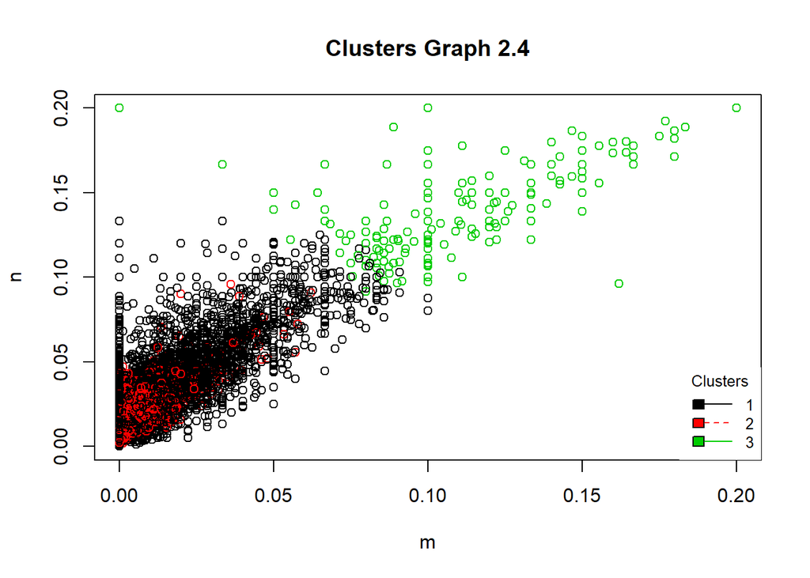

```r
#PLOTS
funct_plot(online_intention$BounceRates, online_intention$ExitRates,
           intention_clusters5$cluster, 2.4) # graph 13
```

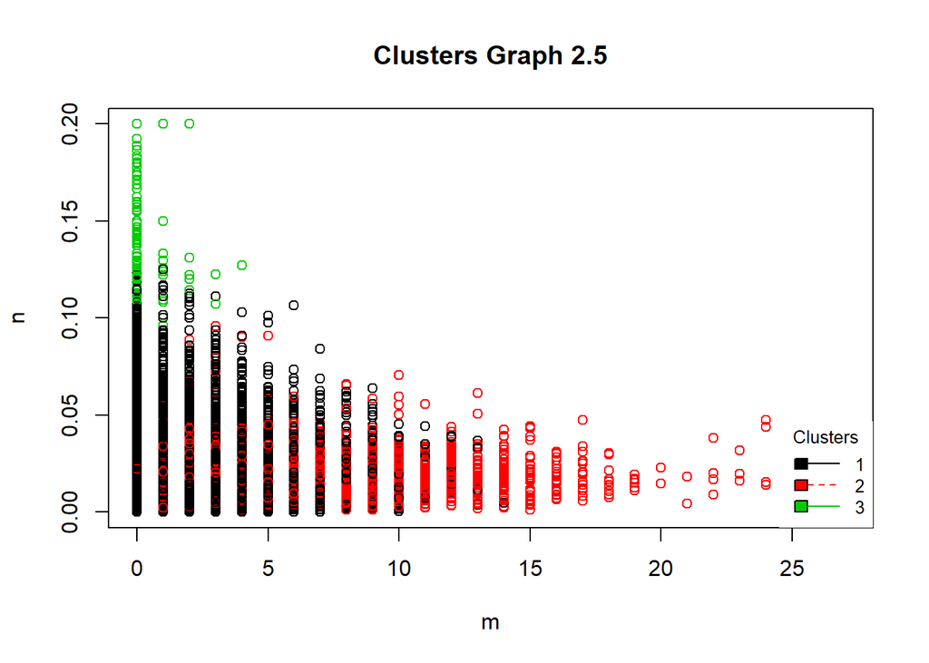

```r
funct_plot(online_intention$Administrative, online_intention$ExitRates,
           intention_clusters5$cluster, 2.5)# graph 14
```

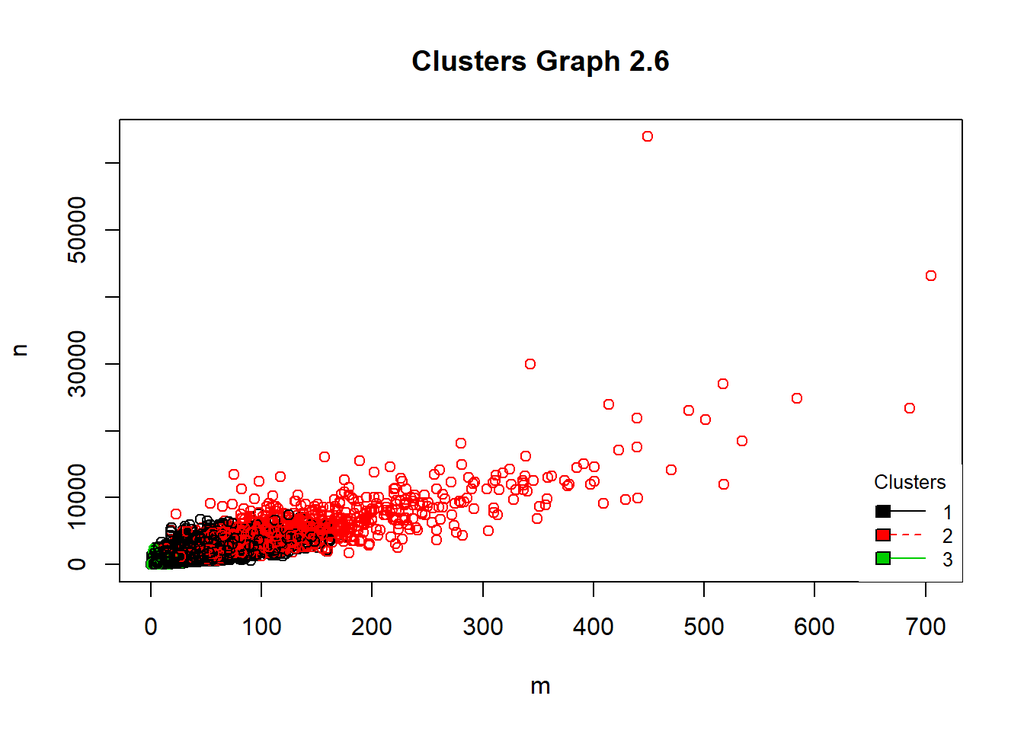

```r
funct_plot(online_intention$ProductRelated, online_intention$ProductRelated_Duration,
           intention_clusters5$cluster, 2.6)# graph 15
```

```r
#get the clusters means
aggregate(intention, by=list(intention_clusters5$cluster), FUN = mean)
```

```
##   Group.1 Administrative Administrative_Duration Informational
## 1       1     1.71607624               51.403018    0.21586907
## 2       2     7.35842073              307.684677    2.53423812
## 3       3     0.04834123                1.414092    0.01611374
##   Informational_Duration ProductRelated ProductRelated_Duration
## 1              8.1427824      23.923037               875.66714
## 2            213.6564125      96.885256              3835.82314
## 3              0.0921327       3.075829                56.55074
##   BounceRates  ExitRates PageValues SpecialDay    Month OperatingSystems
## 1 0.009142508 0.03206092   5.894772 0.06140460 7.581935         2.119847
## 2 0.006283526 0.01944925   9.689339 0.02973473 8.598396         2.112893
## 3 0.166040148 0.18013670   0.000000 0.11033175 6.838863         2.179147
##    Browser   Region TrafficType Return_visitor New_visitor no_weekend
## 1 2.384089 3.194634    4.044645      0.8310545  0.16210897  0.7640356
## 2 2.222702 2.924738    3.603331      0.9376928  0.06045651  0.7458359
## 3 2.316588 3.056872    5.014218      0.9554502  0.02938389  0.8312796
##   no_renevue
## 1  0.8495960
## 2  0.7223936
## 3  0.9943128
```

```r
#append cluster assignment
online_intention <- data.frame(online_intention, intention_clusters5$cluster)
```